# Kostenoffenlegung als Wettbewerbsvorteil

Chancen und Potenziale der Kostentransparenz

# Motivation

Die Untersuchung von Kostentransparenz ist aus ökonomischer Sicht besonders spannend, da sie Einblicke in das Zusammenspiel von Marktverhalten, Preiswahrnehmung und Konsumentenvertrauen ermöglicht. In klassischen Märkten gilt Information als asymmetrisch verteilt - insbesondere Kostenstrukturen bleiben für Konsument:innen meist verborgen. Wenn Unternehmen jedoch freiwillig ihre Produktionskosten offenlegen, entsteht eine neue Form der Marktkommunikation, die sowohl auf das Kaufverhalten als auch auf die Markenbindung Einfluss nehmen kann.

In diesem Projekt beschäftigen Sie sich mit der ökonomischen Wirkung unterschiedlicher Formen von Kostentransparenz, darunter produktbezogene Einzelkosten-Offenlegung im Point-of-Sale oder auch verbal vermittelte Transparenz in Kombination mit Vertrauensmessung. Ziel ist es, zu untersuchen, wie sich diese Varianten auf Zahlungsbereitschaft, Vertrauen und wahrgenommene Preisfairness auswirken.

Kern dieser Ausarbeitung ist die Frage, inwiefern Kostentransparenz eine rationale Kaufentscheidung unterstützt oder über emotionale Mechanismen - etwa durch erhöhte Markenattraktivität - wirkt. Für die Analyse greifen Sie auf ein breites Methodenrepertoire zurück, das ökonomische Modellierung mit experimenteller Verhaltensforschung verbindet, und leisten so einen Beitrag zum besseren Verständnis moderner Konsumentenentscheidungen in transparenten Märkten. Für ihre Analyse verwenden Sie die Daten der folgenden Ausarbeitung:

**Mohan, B., Buell, R. W., & John, L. K. (2020). Lifting the veil: The benefits of cost transparency. Marketing Science, 39(6), 1105-1121.**

# Aufbau der Studie

1. Lesen Sie sich den folgenden Text zum Hintergrund und Aufbau der Studie durch und beantworten Sie nachfolgende Fragen dazu:

Der Ausgangspunkt der betrachteten Untersuchung war ein reales Ereignis: Ein Online-Händler stellte im Dezember 2013 ein hochwertiges Lederportemonnaie zum Verkauf. Einige Wochen später wurde auf den Produktseiten eine Infografik zur Kostenzusammensetzung ergänzt, allerdings versehentlich nur bei drei von fünf Farbvarianten. Obwohl der Händler diesen Fehler nicht beabsichtigte, entstand daraus ein sogenanntes natürliches Experiment, also eine reale Vergleichssituation mit kontrollierbaren Unterschieden. Die Verkäufe konnten analysiert werden, um zu überprüfen, ob die Offenlegung der Produktionskosten einen Einfluss auf das Kaufverhalten hatte.

Dieses natürliche Experiment lieferte erste Hinweise darauf, dass Kostentransparenz wirkt - und war damit die Basis für zwei gezielte Experimente im Labor, die Sie sich in diesem Projekt genauer anschauen sollen. Beide Laborexperimente knüpfen an die reale Ausgangslage an - gehen aber unterschiedliche Forschungsfragen an:

Experiment 1: In einem realitätsnahen Online-Setting wurde untersucht, ob Konsument:innen anders entscheiden, wenn sie Informationen zu Produktionskosten sehen. Hierbei sahen die Teilnehmer:innen eine Produktseite für einen Rucksack von Everlane - entweder mit oder ohne Kostenaufstellung (vgl. Abbildung 1: Kostentransparenz Infografik im Anhang). Zusätzlich wurde ein Vergleichsprodukt von J. Crew gezeigt (ohne Hinweise zur Kostenzusammensetzung). Die Teilnehmer:innen mussten entscheiden, von welchem Anbieter sie lieber einen Gutschein erhalten würden. Das Ziel der Forscher war es zu messen, ob Konsument:innen bei mehr Transparenz auch eher kaufen, folglich sich für diesen Gutschein entscheiden.

Experiment 2: Nachdem Experiment 1 zeigte, dass es einen Effekt der Kostentransparenz gibt, stellt sich die psychologische Anschlussfrage, warum es diesen Effekt gibt und wie dieser festzumachen ist. So sahen die Teilnehmer:innen im 2. Experiment ein fiktives Produkt - eine Schokoladentafel. In der Kontrollgruppe wurden nur übliche Produktinfos gezeigt. In der Treatmentgruppe gab es zusätzlich eine detaillierte Kostenaufstellung (vgl. Abbildung 2: Design der Schokoladenverpackung ohne und mit Kostentransparenz im Anhang). Im Anschluss wurden Vertrauen in die Marke und Kaufbereitschaft durch einen Fragebogen abgefragt. So sollte herausgefunden werden, ob Vertrauen der zentrale psychologische Mechanismus für die Kaufentscheidung der Kund:innen ist.

Beantworten Sie nun folgende Fragen:

1. Welches reale Ereignis war der Auslöser der Forschung?
2. Welche konkrete Verhaltensfrage steht im Mittelpunkt von Experiment 1 - Was wollten die Forscher:innen direkt am Kaufverhalten testen?
3. Welcher psychologische Faktor steht im Zentrum von Experiment 2 - und wie hängt er mit dem Kaufverhalten zusammen?
1. Das reale Ereignis, das die Forschung auslöste, war ein unbeabsichtigtes “natürliches Experiment” bei einem Online-Händler. Im Dezember 2013 ergänzte dieser Händler eine Infografik zur Kostenzusammensetzung für ein hochwertiges Lederportemonnaie auf den Produktseiten. Dies geschah jedoch versehentlich nur bei drei von fünf Farbvarianten des Portemonnaies, wodurch eine direkte Vergleichssituation zwischen transparenten und nicht-transparenten Angeboten entstand.
2. Im Mittelpunkt von Experiment 1 stand die Frage, ob Konsumenten anders entscheiden, das heißt, ob sie eher kaufen, wenn sie Informationen zu den Produktionskosten sehen. Die Forscher wollten direkt am Kaufverhalten testen, ob eine erhöhte Kostentransparenz zu einer höheren Kaufbereitschaft führt. Dies wurde gemessen, indem die Teilnehmer entscheiden mussten, von welchem Anbieter (Everlane mit optionaler Kostenaufstellung oder J. Crew ohne Kosteninfos) sie lieber einen Gutschein erhalten würden, was als Indikator für die Kaufentscheidung diente.
3. Im Zentrum von Experiment 2 stand der psychologische Faktor Vertrauen in die Marke. Nachdem Experiment 1 gezeigt hatte, dass Kostentransparenz einen Effekt auf das Kaufverhalten hat, sollte in Experiment 2 herausgefunden werden, warum dieser Effekt auftritt. Es wurde untersucht, ob Vertrauen der zentrale psychologische Mechanismus ist, der die Kaufentscheidung der Kunden bei Kostentransparenz beeinflusst. Die Hypothese war, dass höhere Transparenz zu mehr Vertrauen führt, was wiederum die Kaufbereitschaft steigert.

Nachdem Sie nun die grundlegende Forschungsidee und Zielsetzung der beiden Experimente kennengelernt haben, befassen wir uns im nächsten Schritt vertiefend mit Experiment 1. Ziel ist es, den genauen Aufbau, sowie das konkrete Verhalten der Teilnehmer:innen besser zu verstehen.

2. Lesen Sie sich den folgenden Text zum Aufbau des ersten Experiments durch und beantworten Sie anschließend Fragen dazu:

Cost transparency refers to the disclosure of the costs to produce a good or provide a service. Although cost transparency is a strategy traditionally employed in the context of supplier-firm relationships, wherein the two-way sharing of cost information between parties facilitates collaboration on cost reduction measures, we investigate its effects within the context of consumer-firm relationships. Information on the costs associated with providing goods and services is rarely shared with consumers, but we provide evidence of when and why voluntarily doing so can increase consumers’ purchase interest. Specifically, building on the psychology of disclosure and trust, we posit that cost transparency, insofar as it represents an act of intimate disclosure, fosters trust. In turn, we propose that this heightened trust increases consumers’ willingness to purchase from the transparent firm. In the sections that follow, we discuss our central predictions and highlight alternative accounts. Then, we present experiments, conducted in the lab and in the field, that document the main effects of cost transparency, its underlying psychological drivers, and conditions that moderate its effects.

This first experiment explores how cost transparency influences consumer preferences in an online shopping context. The study was designed as a between-subjects randomized experiment using an incentive-compatible setup, meaning participants made real choices with the possibility of receiving a tangible reward. A total of 509 U.S.-based participants were recruited through Amazon Mechanical Turk (MTurk). Each participant was randomly assigned to one of two experimental conditions:

- Cost Transparency Condition: Participants were shown a simulated product page for a backpack sold by the retailer Everlane. This page included a cost breakdown infographic, listing the production costs such as materials, labor, transport, and duties, with a clearly stated total cost.
- Control Condition: Participants saw the same backpack from Everlane but without any cost information. In both conditions, participants also saw a comparable backpack from J. Crew, which does not practice cost transparency.

Participants were instructed to view both product pages and then asked which company they would prefer to receive a $50 gift card from. Their response served as the main behavioral outcome, representing a choice between the transparent vs. non-transparent retailer. To ensure accurate interpretation of the presented information, a comprehension check followed the main choice question. Participants were also asked for demographic information such as age, gender, income, and education, to allow for potential control variables in later analysis.

Beantworten Sie nun folgende Fragen:

1. Wie viele Personen nahmen final an dem Experiment teil?
2. Worin bestand der Unterschied zwischen der Transparenzbedingung und der Kontrollbedingung?
3. Welche Anreizstruktur wurde verwendet, um die Entscheidung der Teilnehmenden realistisch zu gestalten?
4. Wie unterschieden sich die beiden gezeigten Onlinehändler im Experiment?
5. Warum wurde im Anschluss an die Entscheidungsfrage ein Verständnischeck durchgeführt?
6. In der Beschreibung des Experiments wird von “between-subjects randomized experiment using an incentive-compatible setup” gesprochen. Was versteht man hierunter im Detail?

*Hinweis:* Für die Beantwortung der letzten Frage können Sie [diesen Artikel (Seite 1-5)](https://www.researchgate.net/publication/268269783_Incentives_in_Experiments_A_Theoretical_Analysis) als Grundlage verwenden.

1. An dem Experiment nahmen insgesamt 509 Personen teil.
2. Der Hauptunterschied zwischen der Transparenzbedingung und der Kontrollbedingung lag in der Bereitstellung von Kosteninformationen. In der Transparenzbedingung sahen die Teilnehmer eine simulierte Produktseite für einen Rucksack von Everlane, die eine detaillierte Infografik mit einer Aufschlüsselung der Produktionskosten wie Materialien, Arbeit, Transport und Zölle sowie den klar angegebenen Gesamtkosten enthielt. In der Kontrollbedingung sahen die Teilnehmer denselben Rucksack von Everlane, jedoch ohne jegliche Kosteninformationen.
3. Um die Entscheidung der Teilnehmer realistisch zu gestalten, wurde eine Anreizstruktur verwendet, die als “incentile-compatible setup” bezeichnet wird. Das bedeutet, die Teilnehmer trafen reale Entscheidungen mit der tatsächlichen Möglichkeit, eine materielle Belohnung zu erhalten. Konkret mussten sie sich entscheiden, von welchem Unternehmen sie einen 50-Dollar-Geschenkgutschein erhalten möchten. Diese reale Belohnung sollte sicherstellen, dass die Teilnehmer ihre Präferenzen ernsthaft und reflektiert äußerten.
4. Im Experiment wurden zwei Onlinehändler gezeigt: Everlane und J. Crew. Everlane war der Händler, dessen Produkt (der Rucksack) in den beiden experimentellen Bedingungen (mit und ohne Kostentransparenz) variiert wurde. J. Crew diente als Vergleichsprodukt, das in beiden Bedingungen gezeigt wurde und bekanntlich keine Kostentransparenz praktiziert. Der Unterschied bestand also darin, dass Everlane im Experiment als der potenziell transparente Anbieter fungierte, während J. Crew den nicht-transparenten Standard darstellte.
5. Ein Verständnischeck wurde im Anschluss an die Entscheidungsfrage durchgeführt, um sicherzustellen, dass die Teilnehmer die präsentierten Informationen, insbesondere die Kostenaufschlüsselung in der Transparenzbedingung, korrekt verstanden und verarbeitet hatten. Dies ist wichtig, um zu gewährleisten, dass die beobachteten Verhaltensunterschiede tatsächlich auf den Unterschieden in der Kostentransparenz beruhen und nicht auf einem Missverständnis der Studienmaterialien.
6. Der Begriff beschreibt ein Experiment, bei dem Teilnehmer zufällig einer von zwei Bedingungen zugewiesen werden (ein “between-subjects randomized experiment”), sodass jede Person nur eine Variante sieht und die Gruppen vergleichbar sind. Ein “incentive-compatible setup” bedeutet, dass die Entscheidungen der Teilnehmer reale, monetäre Konsequenzen haben (hier: ein 50-Dollar-Gutschein), um sicherzustellen, dass sie ihre wahren Präferenzen offenbaren. Laut dem erwähnten Artikel “Incentives in Experiments: A Theoretical Analysis” ist die Zahlung für eine zufällig ausgewählte Entscheidung (Random Decision Selection mechanism) oft der einzige Weg, um Anreizkompatibilität zu gewährleisten, da sie Verzerrungen durch andere Entscheidungen vermeidet.

# Daten

## Datenimport und -aufbereitung

Die Daten, die Sie für die nachfolgenden Analysen verwenden, wurden zu Replikationszwecken von den Autoren der Studie zur Verfügung gestellt und können hier heruntergeladen werden:

**Bhavya Mohan, Ryan W. Buell, Leslie K. John (2020) Lifting the Veil: The Benefits of Cost Transparency. Marketing Science 39(6):1105-1121. mksc.2019.1200.sm1.pdf**

Wir haben die Daten für Sie heruntergeladen und im Unterordner mit dem Namen `Daten` bereitgestellt. Für ihre Analyse werden die Dateien `Experiment1.csv` und `Experiment2.csv` genutzt. Für die Zusatzaufgabe ist die Datei `Experiment3.csv` relevant.

3. Lesen Sie den Datensatz `Experiment1.csv` aus dem Unterordner `Daten` in R ein. Nennen Sie den Datensatz in R `daten_exp1`.

Im Datensatz sind unterschiedliche Variablen enthalten. Weiterhin habe wir Ihnen ein Readme mit den Beschreibungen zu den Variablen bereitgestellt. Nutzen Sie dieses und den Text aus Aufgabe 2, um die Variablen zu beschreiben.

treatment: Diese Variable gibt an, welcher experimentellen Bedingung ein Teilnehmer zugeordnet wurde. Eine 1 steht für die Kosten-Transparenz-Bedingung, bei der die simulierte Produktseite des Everlane-Rucksacks inklusive detaillierter Kostenaufschlüsselung gezeigt wurde. Eine 0 markiert die Kontrollbedingung, bei der dieselbe Everlane-Produktseite ohne Kosteninformationen angezeigt wurde.

everlane: Diese Variable erfasst die Hauptentscheidung der Teilnehmer. Eine 1 bedeutet, dass sich der Teilnehmer für die Everlane-Geschenkkarte entschieden hat, während eine 0 die Wahl der J. Crew-Geschenkkarte anzeigt.

passed: Diese Variable gibt an, ob der Teilnehmer den nach der Entscheidungsfrage durchgeführten Verständnistest bestanden hat. Eine 1 bedeutet, dass der Test bestanden wurde, eine 0, dass der Test nicht bestanden wurde.

email_provided: Diese Variable dokumentiert, ob die Teilnehmer eine E-Mail-Adresse für den Gutschein angegeben haben. Eine 1 steht für “E-Mail-Adresse angegeben”, eine 0 für “Keine E-Mail-Adresse angegeben”.

female: Diese Variable gibt das optional angegebene Geschlecht der Teilnehmer an. Eine 1 steht für weiblich, eine 0 für männlich.

age: Diese Variable erfasst das optional angegebene Alter der Teilnehmer als offene Antwort.

educ: Diese Variable beschreibt den optional angegebenen Bildungsabschluss der Teilnehmer auf einer ordinalen Skala. Die Werte reichen von 1 (Einige Jahre in der Schule) bis 5 (Postgradual/beruflich).

income: Diese Variable zeigt das optional angegebene monatliche Einkommensniveau der Teilnehmer in verschiedenen Kategorien an. Die Werte reichen von 1 (Keines) bis 12 (Weiß nicht/Bevorzuge keine Antwort oder über 10.000 Dollar).

## Deskriptive Analyse

Sie sollten sich im ersten Schritt einen Überblick über ihre Daten verschaffen.

4. Auf Basis des Datensatzes `daten_exp1` aus Aufgabe 3 erstellen Sie eine deskriptive Tabelle mit der Anzahl an Beobachtungen, den Mittelwerten, der Standardabweichungen, dem Median, sowie den Minima und Maxima für alle in `daten_exp1` enthaltenen Variablen.

Beschreiben und interpretieren Sie ihre Tabelle. Gehen Sie insbesondere auf die Verteilungen der einzelnen Variablen ein. Was fällt hier besonders auf.

Statistische Kennwerte der Variablen im Datensatz

| Variable | Beobachtungen | Mittelwert | Standardabweichung | Minimum | Median | Maximum |
| --- | --- | --- | --- | --- | --- | --- |
| treatment | 509 | 0.50 | 0.50 | 0 | 0 | 1 |
| everlane | 509 | 0.63 | 0.48 | 0 | 1 | 1 |
| passed | 509 | 0.77 | 0.42 | 0 | 1 | 1 |
| email provided | 509 | 0.56 | 0.50 | 0 | 1 | 1 |
| female | 509 | 0.49 | 0.50 | 0 | 0 | 1 |
| age | 505 | 37.59 | 11.74 | 18 | 35 | 81 |
| education | 505 | 3.76 | 0.84 | 1 | 4 | 5 |
| income | 505 | 7.58 | 2.43 | 1 | 8 | 12 |

Die Tabelle zeigt für jede Variable die Anzahl der Beobachtungen, den Mittelwert, die Standardabweichung, das Minimum, den Median und das Maximum.

**treatment:** Dies ist eine binäre Variable (kann nur die Werte 0 oder 1 annehmen). Ein Mittelwert von 0.50 bei einer 0/1-Kodierung bedeutet, dass genau 50% der Beobachtungen den Wert 1 haben und 50% den Wert 0. Dies deutet auf eine perfekt ausbalancierte Verteilung zwischen den beiden Gruppen hin (z.B. Treatment-Gruppe und Kontrollgruppe). Der Median von 0 zeigt, dass mindestens die Hälfte der Beobachtungen den Wert 0 hat. Da der Mittelwert aber 0.5 ist, muss die andere Hälfte den Wert 1 haben.

**everlane:** Binäre Variable. Der Mittelwert von 0.63 bedeutet, dass 63% der Beobachtungen den Wert 1 haben und 37% den Wert 0. Der Median ist 1, was bedeutet, dass mindestens die Hälfte der Beobachtungen den Wert 1 hat. Die Verteilung ist hier also nicht ganz ausgeglichen, es gibt mehr Beobachtungen mit dem Wert 1.

**passed:** Binäre Variable. Ein Mittelwert von 0.77 zeigt, dass 77% der Beobachtungen den Wert 1 haben (z.B. Test bestanden) und 23% den Wert 0. Der Median von 1 unterstützt dies, da ein Großteil der Werte 1 ist.

**email provided:** Binäre Variable. 56% der Beobachtungen haben den Wert 1 (z.B. E-Mail-Adresse angegeben), 44% den Wert 0. Der Median von 1 deutet darauf hin, dass etwas mehr als die Hälfte der Beobachtungen den Wert 1 hat.

**female:** Binäre Variable, die vermutlich das Geschlecht abbildet (z.B. 1 für weiblich, 0 für männlich). Ein Mittelwert von 0.49 bedeutet, dass 49% der Beobachtungen den Wert 1 (weiblich) und 51% den Wert 0 (männlich) haben. Der Median von 0 zeigt, dass etwas mehr als die Hälfte der Personen nicht weiblich sind (also männlich, wenn es nur diese zwei Kategorien gibt). Die Verteilung ist hier also sehr nah an einer Gleichverteilung.

**age:** Metrische Variable. Das Durchschnittsalter liegt bei ca. 37.6 Jahren. Der Median liegt bei 35 Jahren. Da der Mittelwert (37.59) leicht höher ist als der Median (35), deutet dies auf eine leichte Rechtsschiefheit der Verteilung hin. Das bedeutet, es gibt einige Ausreißer mit höherem Alter, die den Mittelwert nach oben ziehen. Die Standardabweichung von 11.74 zeigt eine moderate Streuung der Alterswerte um den Mittelwert. Die Altersspanne reicht von 18 bis 81 Jahren.

**education:** Diese Variable scheint kategorial oder ordinal zu sein, wahrscheinlich Bildungsstufen kodiert von 1 bis 5. Der Mittelwert liegt bei 3.76, der Median bei 4. Da der Median (4) höher ist als der Mittelwert (3.76), könnte dies auf eine leichte Linksschiefe hindeuten oder darauf, dass die Kategorie “4” sehr häufig vorkommt. Die meisten Personen haben also eher einen höheren Bildungsabschluss in dieser Skala. Die Standardabweichung ist relativ gering, was auf eine Konzentration der Werte hindeutet.

**income:** Ähnlich wie “education” scheint dies eine kategoriale oder ordinale Variable für Einkommensklassen zu sein (Skala von 1 bis 12). Der Mittelwert beträgt 7.58, der Median liegt bei 8. Auch hier ist der Median (8) leicht höher als der Mittelwert (7.58), was auf eine leichte Linksschiefe oder eine Konzentration im oberen Bereich der mittleren Kategorien hindeutet. Die Standardabweichung von 2.43 zeigt eine gewisse Streuung über die Einkommensklassen.

**Was fällt besonders auf**

**Fehlende Werte:** Bei den Variablen “age”, “education” und “income” gibt es jeweils 4 fehlende Beobachtungen (505 statt 509). Dies ist wichtig zu berücksichtigen, falls weitere Analysen geplant sind, da entschieden werden muss, wie mit diesen fehlenden Werten umgegangen wird.

**Binäre Variablen:** “treatment” ist perfekt balanciert (50/50). “female” ist nahezu balanciert. “everlane”, “passed” und “email provided” zeigen eine deutlichere Tendenz zu einem der beiden Werte (mehrheitlich 1). Bei “passed” ist dies mit 77% besonders ausgeprägt.

**Verteilung von “age”:** Die leichte Rechtsschiefheit beim Alter ist typisch für viele Populationen.

**Verteilung von “education” und “income”:** Beide Variablen zeigen, dass der Median leicht über dem Mittelwert liegt, was auf eine Tendenz zu höheren Kategorien in der Skala hindeutet bzw. eine leichte Linksschiefe. Dies könnte bedeuten, dass ein größerer Anteil der Befragten in den mittleren bis höheren Bildungs- bzw. Einkommensklassen angesiedelt ist.

**Standardabweichungen der binären Variablen:** Die Standardabweichung einer binären Variable, die mit 0 und 1 kodiert ist, ist maximal, wenn p=0.5 (wobei p der Anteil der 1en ist) und beträgt dann 0.5. Dies sehen wir bei “treatment” und annähernd bei “female” und “email provided”. Bei “everlane” und besonders bei “passed” ist sie geringer, da die Verteilung unausgeglichener ist.

5. Im Datensatz `daten_exp1` gibt es Variablen für die keine Beobachtungen vorhanden sind.
- Gegeben ihrer Variablenbeschreibung in Aufgabe 3:
  - Macht es Sinn die Beobachtungen aus dem Datensatz zu entfernen, wenn für bestimmte Variablen keine Werte vorhanden sind?
  - Wenn ja, warum?
  - Wie viele Beobachtungen entfernen Sie dadurch aus ihrem Datensatz?

Entfernen Sie nun alle Beobachtungen (d.h. gesamte Zeilen aus dem Datensatz), bei denen für mindestens eine der erhobenen Variablen kein Wert vorliegt, da unvollständige Daten für die Analyse nicht berücksichtigt werden sollen.

Untersuchen Sie weiterhin, ob sich die Teilnehmer, die die Webseite mit der Kostentransparenz gesehen haben (Treatmentgruppe), systematisch von jenen unterscheiden, die die Kontrollversion gesehen haben. Auch wenn es sich um ein Experiment handelt, bei dem die Zuteilung zu den Gruppen zufällig erfolgt ist, sollten Sie dennoch prüfen, ob es unbeabsichtigte (systematische) Unterschiede zwischen den Gruppen gibt. Erstellen Sie hierfür eine Balancing-Tabelle, in der Sie die Mittelwerte von Alter (age), Geschlecht (female), Einkommensstufe (income) und Bildungsniveau (educ) zwischen den beiden Gruppen vergleichen, die Differenzen berechnen und mithilfe von T-Tests prüfen, ob diese Unterschiede statistisch signifikant sind.

- Beschreiben und interpretieren Sie ihre Tabelle.
  - Was fällt Ihnen in Bezug auf die p-Werte auf?
  - Was müssten Sie bei einer weiteren Regressionsanalyse berücksichtigen?

*Hinweis:* Die beiden Gruppen, die Sie in der Balancing Tabelle betrachten sollen, können aus den Werten (1 und 0) der Variable `treatment` abgeleitet werden.

Balancing-Tabelle für die Grundcharakteristika der Teilnehmer (Baseline)

[output not shown]

Note:  
Die Tabelle vergleicht die Mittelwerte wichtiger soziodemografischer Variablen zwischen Treatment- und Kontrollgruppe. Signifikante Unterschiede weisen auf mögliche Ungleichverteilungen trotz Randomisierung hin.

Die dargestellte Tabelle ist eine Balancing-Tabelle für die Grundcharakteristika der Teilnehmer (Baseline). Sie vergleicht Mittelwerte wichtiger soziodemografischer Variablen zwischen der Treatment- und der Kontrollgruppe zu Beginn (Baseline) einer Studie. Die Gesamtstichprobe beträgt N = 505.

**Macht es Sinn, Beobachtungen mit fehlenden Werten zu entfernen?**

Wenn die Analyse auf vollständigen Datensätzen basiert (z.B. Vergleich von Gruppen oder Regressionsanalysen), ist es wichtig, unvollständige Beobachtungen zu entfernen. Ansonsten kann es zu Verzerrungen oder zu nicht vergleichbaren Gruppen kommen.

Die Tabelle prüft, ob sich die Treatment- und Kontrollgruppe (N=505) bei wichtigen Grundmerkmalen (Alter, Geschlecht, Einkommen, Bildung) vor Beginn der Intervention unterscheiden. Ziel ist es, eine erfolgreiche Randomisierung zu bestätigen, bei der es idealerweise keine signifikanten Unterschiede gibt (hohe p-Werte).

**Alter, Geschlecht und Bildungsniveau:** Diese Merkmale sind gut zwischen den Gruppen balanciert (p-Werte: 0.54 für Alter, 0.96 für Geschlecht, 0.42 für Bildung). Das bedeutet, es gibt hier keine statistisch signifikanten Unterschiede.

**Was fällt bei den p-Werten auf?** Die meisten p-Werte sind hoch, was gut ist und für eine erfolgreiche Randomisierung spricht. Der p-Wert von 0.10 für die Einkommensstufe ist jedoch der auffälligste und signalisiert eine potenzielle, wenn auch nicht stark signifikante, Unausgewogenheit.

**Was ist bei einer Regressionsanalyse zu berücksichtigen?**

Wegen der potenziellen Unausgewogenheit bei der Einkommensstufe (p=0.10) sollte diese Variable unbedingt als Kontrollvariable (Kovariate) in die Regressionsanalyse aufgenommen werden. Dies hilft, den Einfluss dieses Unterschieds auf den geschätzten Treatment-Effekt herauszurechnen und somit eine genauere und verlässlichere Aussage über die Wirksamkeit des Treatments zu treffen. Auch die anderen gut balancierten Variablen könnten zur Erhöhung der Präzision als Kontrollen dienen.

Nachdem Sie sich in den vorangegangenen Aufgaben bereits mit der Verteilung der Daten und den Unterschieden zwischen den einzelnen Gruppen auseinandergesetzt haben, geht es nun um eine explorative Betrachtung von Zusammenhängen zwischen den zentralen Variablen im Datensatz.

6. In dieser Aufgabe führen Sie eine Korrelationsanalyse durch, um herauszufinden, ob und wie stark einzelne Merkmale - wie Alter, Bildung, Einkommen oder Geschlecht - mit der Treatment-Zugehörigkeit sowie der Entscheidung für die Everlane-Gutscheinkarte zusammenhängen.

Wählen Sie die folgenden Variablen aus dem Datensatz `daten_exp1` aus:

- treatment
- everlane
- age
- income
- educ
- female

Berechnen Sie die Korrelationsmatrix dieser Variablen. Visualisieren Sie die Matrix (als Tabelle oder Grafik), in der die Korrelationskoeffizienten und deren Stärke farblich dargestellt sind.

Beschreiben und interpretieren Sie ihre Tabelle/Grafik. Gehen Sie hierbei auch auf folgende Fragen ein:

- Was bedeutet ein positiver Zusammenhang (Korrelation) zwischen `treatment` und `everlane` im Kontext der Hypothese, dass Kostentransparenz die Entscheidung für Everlane beeinflusst?
- Warum kann eine Korrelation auf einen Zusammenhang hinweisen, aber nicht ausreichen, um einen kausalen Effekt nachzuweisen - selbst wenn wir wissen, dass `treatment` im Experiment zufällig zugewiesen wurde?
- Was nützt ihnen eine Korrelationsmatrix im Vergleich zu einem einfachen Mittelwertvergleich zwischen den Gruppen?

*Hinweis:* Für die Darstellung der Korrelationsmatrix können Sie z.B. das Paket corrplot verwenden.

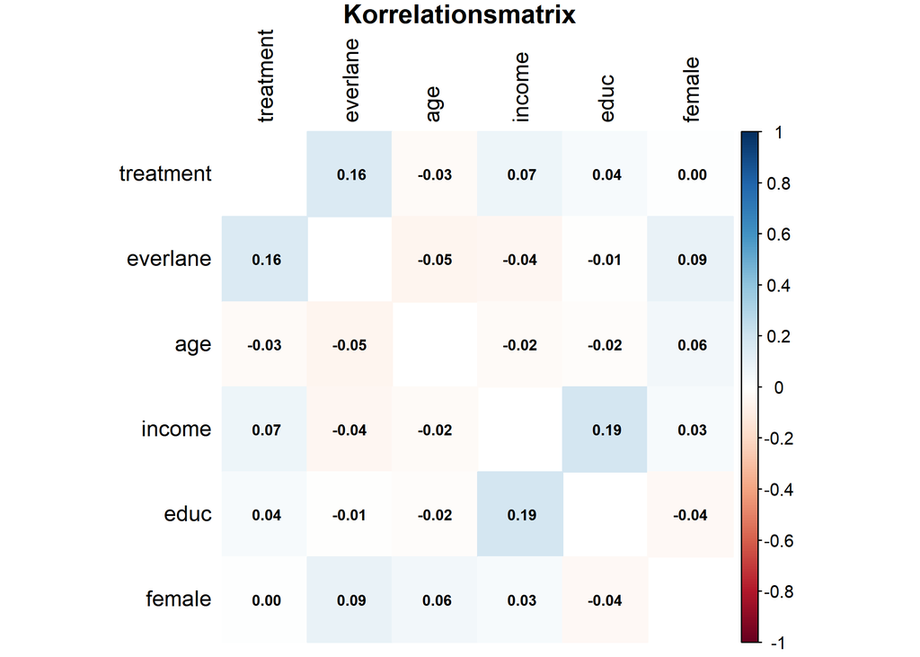

**Beschreibung:**  
Die vorliegende Korrelationsmatrix zeigt die Pearson-Korrelationskoeffizienten für die Variablen treatment, everlane, age, income, educ und female. Jeder Koeffizient liegt zwischen -1 und +1. Werte nahe 0 deuten auf keinen oder einen sehr schwachen linearen Zusammenhang hin, während Werte nahe +1 oder -1 auf einen starken positiven bzw. negativen linearen Zusammenhang deuten.

**Interpretation:**  
Basierend auf den bereitgestellten Werten können wir folgende Beobachtungen machen. Der Zusammenhang zwischen treatment und everlane beträgt 0.16. Dies ist eine positive, aber eher schwache Korrelation, die auf eine leichte Tendenz hindeutet, dass Kostentransparenz mit der Wahl der Everlane-Geschenkkarte einhergeht. Die Korrelationen zwischen treatment und den demografischen Variablen age (-0.03), income (0.07), educ (0.04) und female (0.00) sind extrem schwach. Dies bestätigt die erfolgreiche Randomisierung der Teilnehmer, da die Gruppen hinsichtlich dieser Merkmale gut ausbalanciert sind. Die Zusammenhänge zwischen den demografischen Variablen und everlane sind ebenfalls sehr schwach: everlane und age (-0.05), everlane und income (-0.04), everlane und educ (-0.01), sowie everlane und female (0.09). Dies deutet darauf hin, dass diese Merkmale die Entscheidung für Everlane nicht stark linear beeinflussen. Unter den demografischen Variablen zeigen age und income (-0.02) sowie age und educ (-0.02) überraschend schwache oder leicht negative Korrelationen, während income und educ eine schwache positive Korrelation von 0.19 aufweisen.

**Was bedeutet ein positiver Zusammenhang (Korrelation) zwischen treatment und everlane im Kontext der Hypothese, dass Kostentransparenz die Entscheidung für Everlane beeinflusst?**  
Ein positiver Korrelationskoeffizient von 0.16 zwischen treatment und everlane bedeutet, dass die Kostentransparenz-Bedingung leicht mit einer erhöhten Wahl der Everlane-Geschenkkarte assoziiert ist. Im Kontext der Hypothese deutet dies darauf hin, dass Kostentransparenz die Präferenz der Konsumenten für Everlane leicht positiv beeinflusst. Es ist ein erster Hinweis, der die Hypothese unterstützt, auch wenn der lineare Zusammenhang schwach ist.

**Warum kann eine Korrelation auf einen Zusammenhang hinweisen, aber nicht ausreichen, um einen kausalen Effekt nachzuweisen - selbst wenn wir wissen, dass treatment im Experiment zufällig zugewiesen wurde?**  
Eine Korrelation (hier 0.16) zeigt lediglich eine Beziehung, nicht unbedingt eine Ursache-Wirkung. Obwohl die Randomisierung der treatment-Variable die Grundlage für kausale Schlüsse legt, reicht die Korrelation allein nicht aus, um einen kausalen Effekt zu beweisen. Andere Faktoren könnten die Korrelation beeinflussen oder sie könnte zufällig sein. Um Kausalität zu belegen und die statistische Signifikanz zu prüfen, sind spezifische statistische Tests wie Mittelwertvergleiche (z.B. t-Tests) oder Regressionsanalysen erforderlich.

**Was nützt ihnen eine Korrelationsmatrix im Vergleich zu einem einfachen Mittelwertvergleich zwischen den Gruppen?**  
Ein Mittelwertvergleich ist ideal, um den direkten kausalen Effekt von treatment auf everlane zu testen. Die Korrelationsmatrix hingegen bietet einen umfassenderen, explorativen Überblick über alle paarweisen linearen Zusammenhänge. Sie ist nützlich, um die erfolgreiche Randomisierung zu überprüfen (Korrelationen von treatment mit Demografie nahe Null, z.B. 0.00 für female), potenzielle Multikollinearität (z.B. zwischen age und income mit -0.02, oder income und educ mit 0.19) zu identifizieren und mögliche Kontrollvariablen für komplexere Modelle zu erkennen. Sie dient der Datenexploration und der Validierung des Studiendesigns über die reine Hypothesenprüfung hinaus.

7. In Aufgabe 1 und 2 haben Sie gelesen, dass den Teilnehmern ein Angebot gemacht wurde, eine Everlane-Gutscheinkarte anzunehmen. Erzeugen Sie eine geeignete Grafik, die den durchschnittlichen Anteil der angenommenen Angebote (d.h. den Anteil, in dem die Everlane-Karte gewählt wurde) getrennt für die Treatment- und die Kontrollgruppe darstellt. Fügen Sie in der Grafik zusätzlich den Standardfehler der Mittelwerte ein. Führen Sie einen T-Test durch, um zu prüfen, ob der Unterschied im Mittelwert zwischen der Treatment- und Kontrollgruppe statistisch signifikant ist, und geben Sie das Testergebnis (den p-Wert) deutlich sichtbar in der Grafik an. Achten Sie dabei auf eine verständliche Beschriftung Ihrer Grafik sowie auf einen aussagekräftigen Titel.

Beschreiben und interpretieren Sie ihre Grafik. Gehen Sie insbesondere auf folgende Fragen ein:

- Welche Aussage lässt sich auf Basis des durchgeführten T-Tests treffen?
- Welche der in den vorherigen Aufgaben (vgl. Aufgabe 4 und 5) analysierten Faktoren könnten dazu beigetragen haben, dass ein signifikanter Unterschied im Anteil angenommener Everlane-Angebote zwischen Treatment- und Kontrollgruppe beobachtet wird?

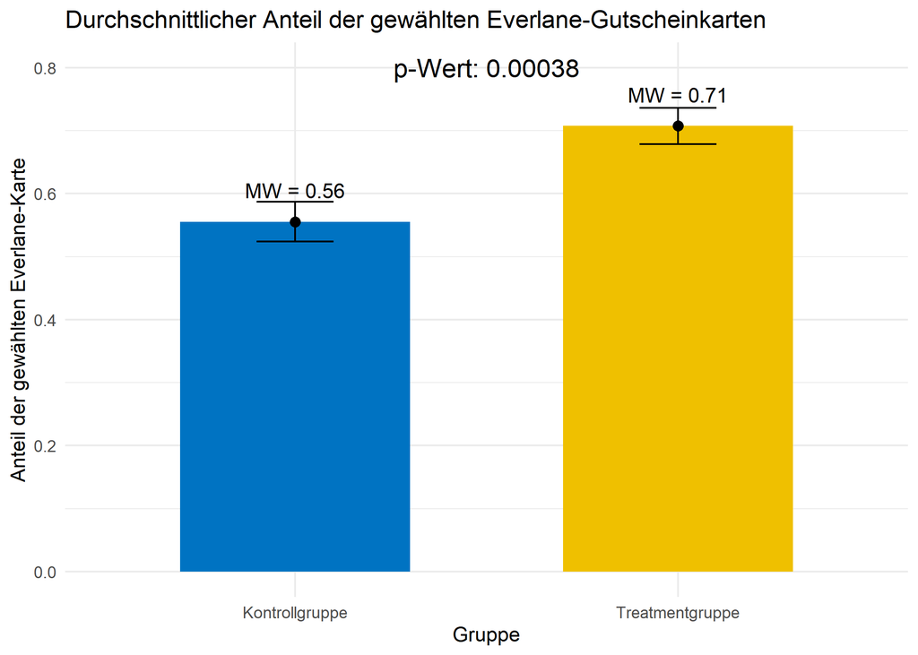

**Beschreibung der Grafik:**  
Die vorliegende Grafik stellt den durchschnittlichen Anteil der angenommenen Everlane-Angebote dar, aufgeteilt nach der experimentellen Bedingung. Der linke Balken repräsentiert die “Kontrolle”-Gruppe, bei der keine Kostentransparenz gegeben war, und der rechte Balken die “Kosten-Transparenz”-Gruppe, die die detaillierten Kosteninformationen erhielt. Die Höhe jedes Balkens visualisiert den durchschnittlichen Anteil der Everlane-Wahl in der jeweiligen Gruppe. Die schwarzen vertikalen Linien auf den Balken sind die Standardfehler der Mittelwerte, welche die Präzision der Schätzung des wahren Gruppenmittelwerts anzeigen. Über den Balken ist der p-Wert des durchgeführten T-Tests als “p-Wert: 0.00038” angegeben, was die statistische Signifikanz des Unterschieds hervorhebt.

**Interpretation der Grafik:**  
Die Grafik zeigt eine klare visuelle Evidenz für einen Unterschied in der Wahl der Everlane-Geschenkkarte zwischen den beiden experimentellen Bedingungen. Der Balken für die Gruppe mit Kostentransparenz ist deutlich höher als der für die Kontrollgruppe, was darauf hindeutet, dass ein größerer Anteil der Teilnehmer sich für Everlane entschied, wenn ihnen die Kosten transparent gemacht wurden. Die Standardfehlerbalken überlappen sich nicht, was die visuelle Einschätzung eines Unterschieds verstärkt und bereits auf statistische Signifikanz hindeutet. Dieser grafische Befund stimmt mit unserer Hypothese überein, dass Kostentransparenz die Präferenz für den transparenten Anbieter erhöhen könnte. Die Darstellung ermöglicht es, den Effekt der Intervention direkt zu erfassen und die Größenordnung des Unterschieds zwischen den Gruppen zu vergleichen. Es wird deutlich, dass die Kostentransparenz nicht nur einen marginalen, sondern einen substanziellen Unterschied in der Akzeptanz des Angebots bewirkt hat.

**Welche Aussage lässt sich auf Basis des durchgeführten T-Tests treffen?**  
Der in der Grafik angezeigte p-Wert von 0.00038 ist extrem klein und liegt weit unter gängigen Signifikanzniveaus. Dies bedeutet, dass der beobachtete Unterschied im Anteil angenommener Everlane-Angebote zwischen der Kosten-Transparenz- und der Kontrollgruppe statistisch hochsignifikant ist. Wir können mit hoher Sicherheit annehmen, dass die Kostentransparenz einen positiven und bedeutsamen Einfluss auf die Wahl der Everlane-Geschenkkarte hatte.

**Welche der in den vorherigen Aufgaben (vgl. Aufgabe 4 und 5) analysierten Faktoren könnten dazu beigetragen haben, dass ein signifikanter Unterschied im Anteil angenommener Everlane-Angebote zwischen Treatment- und Kontrollgruppe beobachtet wird?**  
Die Analysen aus den Aufgaben 4 und 5 zeigen, dass die experimentellen Gruppen bezüglich der demografischen Merkmale (Alter, Geschlecht, Bildung, Einkommen) gut ausbalanciert waren, da die entsprechenden p-Werte für die Mittelwertvergleiche zwischen den Gruppen hoch (z.B. 0.54 für Alter, 0.96 für Geschlecht) oder nur geringfügig signifikant (0.10 für Einkommen) waren. Dies bedeutet, dass diese Faktoren nicht systematisch zwischen den Gruppen variierten und somit unwahrscheinlich zur Erklärung des signifikanten Unterschieds im Everlane-Anteil beitragen. Der entscheidende Faktor, der den beobachteten signifikanten Unterschied erklärt, ist die experimentelle Manipulation selbst: die Kostentransparenz.

In den vorherigen Aufgaben des Projekts haben Sie sich bereits intensiv mit dem Experiment 1 auseinandergesetzt, in dem untersucht wurde, ob und wie die Offenlegung von Produktionskosten - also Kostentransparenz - das Konsumverhalten beeinflusst. Es wurde gezeigt: Wenn Konsument:innen transparent mitgeteilt wird, wie sich die Kosten eines Produkts zusammensetzen, steigt ihre Bereitschaft, bei dem entsprechend transparenten Unternehmen einzukaufen.

Diese Ergebnisse legen nahe, dass die Offenlegung sensibler Unternehmensinformationen (wie Produktionskosten) das Vertrauen der Konsument:innen in das Unternehmen stärkt und sie somit eher zu einem Kauf motiviert.

Doch was genau ist der psychologische Mechanismus hinter dieser Wirkung? Ist es tatsächlich das Vertrauen in das Unternehmen, das durch die Offenlegung sensibler Informationen gestärkt wird - und in der Folge die Kaufbereitschaft erhöht?

Um genau diese Frage zu beantworten, führen die Autoren ein weiteres Experiment durch, das den vermuteten psychologischen Vermittlungsmechanismus des Vertrauens genauer untersucht. Dabei wurde geprüft, ob Vertrauen tatsächlich als Mediator zwischen Kostentransparenz und Kaufinteresse wirkt. Hierzu wurde ein kontrolliertes Online-Experiment mit über 600 Teilnehmer:innen durchgeführt. Die Teilnehmenden wurden zufällig einer von zwei Bedingungen zugewiesen:

- In der **Kostentransparenz-Gruppe** (Treatment) wurde zusätzlich eine detaillierte Aufschlüsselung der Produktionskosten angegeben. Diese beinhaltete die einzelnen Kostenkomponenten (z.B. Kakaobutter, Verpackung, Arbeitskosten) sowie die Gesamtkosten der Schokoladentafel (vgl. Abbildung 2 im Anhang).
- In der **Kontrollgruppe** sahen die Teilnehmer die Verpackung einer fiktiven Schokoladenmarke namens „Cocoa Passion“. Diese enthielt nur die üblichen Informationen wie Zutaten, Nährwerte und eine Produktbeschreibung.

Ziel war es, zu untersuchen, ob die Offenlegung dieser sensiblen Informationen das Vertrauen der Konsument:innen in die Marke stärkt - und ob dieses Vertrauen wiederum die Kaufbereitschaft beeinflusst. In den nächsten Aufgaben werden Sie diese Studie genauer beleuchten, analysieren und evaluieren, ob sich die Hypothese empirisch bestätigen lässt.

8. Lesen Sie die Daten des zweiten Experiments (`Experiment2.csv`) in R ein. Nennen Sie den Datensatz `daten_exp2`. Benennen Sie die Variable `cost` in `treatment` um.

Untersuchen Sie, ob sich die Teilnehmer, die die Verpackung mit transparenter Kosteninformation gesehen haben, systematisch von jenen unterscheiden, die nur die Kontrollversion gesehen haben.

Erstellen Sie hierfür eine Balancing-Tabelle, in der Sie die Mittelwerte von Alter (age), Geschlecht (female), Einkommensstufe (income), Bildungsniveau (educ), Vertrauen (trust) und Kaufbereitschaft (wtb) zwischen den beiden Gruppen vergleichen, die Differenzen berechnen und mithilfe von T-Tests prüfen, ob diese Unterschiede statistisch signifikant sind. Nehmen Sie weiterhin die Anzahl an Beobachtungen in der Treatment- und in der Kontrollgruppe in ihre Tabelle mit auf.

Beschreiben und interpretieren Sie ihre Tabelle. Gehen Sie dabei insbesondere auf folgende Fragen ein:

- Was versteht man unter der Variable `wtb`?
- Was lässt sich aus der Größen der Stichprobe ableiten?
- Wo könnte es bei einer Regression (oder einem sonstigen Vergleich der Gruppen) zu Problemen kommen und was wären mögliche Auswirkungen?

*Hinweis:* Für die Beschreibung der `wtb` können Sie das bereitgestellte Readme nutzen.

Balancing-Tabelle für Experiment 2 (N = 639)

| Variable | Stichprobe Experiment 2 (N = 639) Treatment | Stichprobe Experiment 2 (N = 639) Kontrolle | Stichprobe Experiment 2 (N = 639) Differenz | Stichprobe Experiment 2 (N = 639) p-Wert |
| --- | --- | --- | --- | --- |
| Alter | 34.06 | 36.27 | -2.21 | 0.02 |
| Geschlecht | 0.48 | 0.42 | 0.06 | 0.21 |
| Einkommensstufe | 6.79 | 6.96 | -0.17 | 0.37 |
| Bildungsniveau | 3.57 | 3.51 | 0.06 | 0.44 |
| Vertrauen | 5.27 | 4.82 | 0.45 | 0.00 |
| Kaufbereitschaft | 4.27 | 3.74 | 0.53 | 0.00 |

Note:  
Die Tabelle vergleicht die Mittelwerte zentraler Variablen zwischen Treatment- und Kontrollgruppe. Signifikante Unterschiede könnten auf Selektionseffekte hindeuten.

Die dargestellte Tabelle ist eine Balancing-Tabelle für Experiment 2 mit einer Stichprobengröße von N = 639. Sie zeigt die Mittelwerte zentraler Variablen in der Treatment- und Kontrollgruppe, um zu überprüfen, ob die Gruppen zu Beginn vergleichbar sind. Dies ist wichtig, um sicherzustellen, dass Unterschiede in den Ergebnissen später tatsächlich auf die Behandlung und nicht auf bestehende Unterschiede zurückzuführen sind.

**Was versteht man unter der Variable `wtb`?** Die Variable wtb (willingness to buy) misst die Kaufbereitschaft der Teilnehmer. Dabei handelt es sich um eine 7-Punkte-Likert-Skala: 1 = Überhaupt nicht wahrscheinlich 7 = Sehr wahrscheinlich → Höhere Werte bedeuten also eine stärkere Kaufabsicht.

**Was lässt sich aus der Größe der Stichprobe ableiten?** Die Stichprobe besteht aus 639 Personen, aufgeteilt auf: Treatment-Gruppe (Verpackung mit transparenter Kosteninformation) Kontrollgruppe (Standardverpackung) → Diese relativ große Stichprobe erlaubt: verlässliche Mittelwertvergleiche ausreichende statistische Power, um signifikante Unterschiede zu erkennen robustere Schätzungen in späteren Regressionsanalysen

Diese Auffälligkeiten deuten darauf hin, dass es trotz Randomisierung zu gewissen Ungleichgewichten gekommen sein könnte. Insbesondere die signifikanten Unterschiede in Vertrauen und Kaufbereitschaft legen nahe, dass die transparente Kosteninformation möglicherweise bereits vor einer weiteren Analyse einen Einfluss ausgeübt hat – oder dass andere, unbeobachtete Faktoren eine Rolle spielen. Diese potenziellen Verzerrungen sollten in weiterführenden Analysen, etwa durch Kontrolle von Kovariaten in einer Regressionsanalyse, berücksichtigt werden.

**Wo könnte es bei einer Regression oder einem Gruppenvergleich zu Problemen kommen?**

1. Ungleichverteilung wichtiger Ausgangsvariablen Alter und Vertrauen unterscheiden sich signifikant zwischen Gruppen. Diese Unterschiede könnten nicht durch die Treatment-Bedingung, sondern durch systematische Unterschiede in der Stichprobe entstehen. → Risiko: Verzerrung der Effektschätzung.
2. Selektionseffekte Wenn z.B. jüngere Teilnehmer zufällig häufiger im Treatment sind, könnte das den Unterschied in wtb erklären.
3. Konsequenz für die Analyse Regressionen sollten Kontrollvariablen enthalten → Ohne Kontrolle könnten die Effekte des Treatments überschätzt oder unterschätzt werden.
9. In ihrem Datensatz gibt es einige Beobachtungen ohne vorhandene Werte. Behalten Sie nur die Beobachtungen bei denen vollständige Werte vorliegen. Erzeugen Sie eine geeignete Grafik, welche den durchschnittlichen Anteil der ‘Kaufbereitschaft’ im zweiten Experiment für die Treatment- und Kontrollgruppe darstellt.

Die Grafik soll:

- die Mittelwerte der Kaufbereitschaft für beide Gruppen zeigen,
- die zugehörigen Standardfehler als Fehlerbalken visualisieren und
- das Ergebnis des T-Tests, der die Mittelwertdifferenz prüft, direkt in die Grafik integrieren.

Beschreiben und interpretieren Sie ihre Grafik.

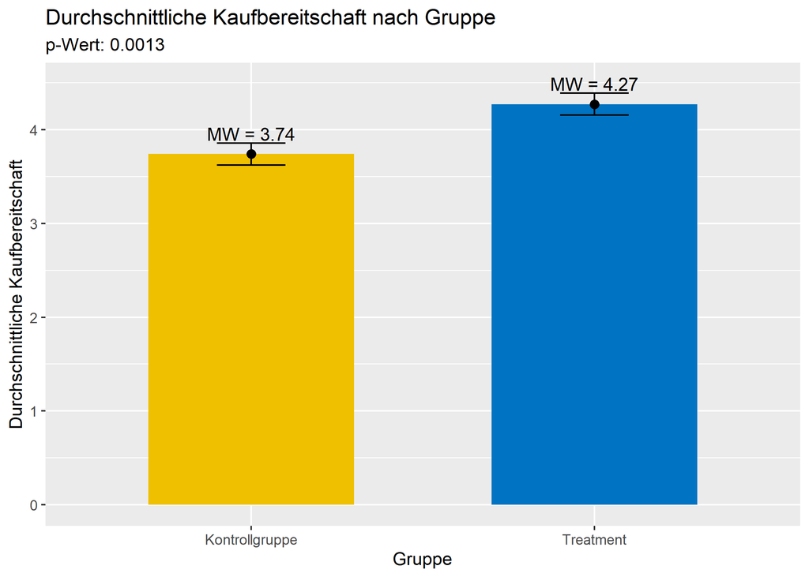

**Beschreibung und Interpretation:** Die Grafik zeigt die durchschnittliche Kaufbereitschaft auf einer Skala von 1 (gering) bis 7 (hoch) für zwei Gruppen: die Kontrollgruppe (gelb) und die Treatmentgruppe (blau). Die x-Achse bildet die Gruppenzugehörigkeit ab, während die y-Achse den Mittelwert der Kaufbereitschaft je Gruppe darstellt. Die Balken sind farblich codiert, wodurch eine klare visuelle Trennung der Gruppen ermöglicht wird. Oberhalb der Balken sind die Mittelwerte der Gruppen, als Punkt, dargestellt, ergänzt durch Fehlerbalken, die den Standardfehler des Mittelwerts anzeigen.

Nachdem Sie nun die Differenzen in der Kaufabsicht zwischen der Treatment- und der Kontrollgruppe im zweiten Experiment überprüft und getestet haben, geht es im nächsten Schritt darum, den möglichen Mediator Vertrauen genauer zu untersuchen. Hierfür sollen Sie sich in einem ersten Schritt das Vertrauen der Personen allgemein anschauen, um einen Eindruck zu dieser wichtigen Variable zu bekommen. Dafür werden Personen anhand **hohem und niedrigem** Vertrauen und deren Kaufbereitschaft für das Produkt unterteilt.

10. Erstellen Sie eine oder mehrere geeignete Grafik(en), die den Zusammenhang zwischen Vertrauen (Trust) und der Kaufabsicht (WTB) **unabhängig** der beiden Treatment- und Kontrollgruppen darstellen. Achten Sie auf eine passende Darstellung der Informationen.

Die Grafik(en) sollen folgende Informationen enthalten:

- Unterteilen Sie ihre Daten in Personen mit `hohem` und `niedrigem` Vertrauen. Nutzen Sie für die Unterteilung den Median des Vertrauens in ihren Daten als Schwellenwert.
- Abhängig der Einstufungen in `hohes` und `niedriges` Vertrauen soll nun die durchschnittliche Kaufbereitschaft dargestellt werden. Hier soll die Grafik so dargestellt werden, dass auf der x-Achse das Vertrauensniveau (“hoch” und “niedrig”) und auf der y-Achse die entsprechende Kaufbereitschaft abgebildet wird.
- Berechnen Sie weiterhin die Mittelwerte der beiden Vertrauensgruppen und visualisieren diese in geeigneter Art und Weise in ihren Grafik(en).
- Führen Sie einen t-Test durch, um zu prüfen, ob die Mittelwertsunterschiede zwischen den beiden Vertrauensgruppen statistisch signifikant sind. Geben Sie den p-Wert in der Grafik an.

Beschreiben und interpretieren Sie ihre Grafik(en). Beantworten Sie insbesondere folgende Fragen:

- Welche Implikationen hat ein signifikanter Unterschied für die Rolle von Vertrauen auf Kaufentscheidungen?
- Wie stark unterscheidet sich die Kaufbereitschaft zwischen Personen mit hohem und niedrigem Vertrauen?
- Könnte auf Basis ihrer Darstellung Vertrauen als Mediator zwischen dem Treatment und der Kaufbereitschaft fungieren?

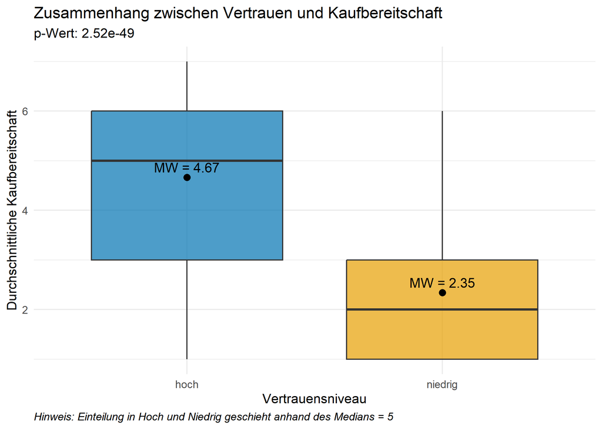

**Beschreibung und Interpretation:** Die Grafik zeigt die durchschnittliche Kaufbereitschaft auf einer Skala von 1 (gering) bis 7 (hoch) für zwei Gruppen: Personen mit hohem Vertrauen (blau) und Personen mit niedrigem Vertrauen (gelb). Die x-Achse bildet das Vertrauensniveau ab, während die y-Achse den Mittelwert der Kaufbereitschaft je Gruppe darstellt. Die Darstellung erfolgt in Form von Boxplots, ergänzt durch eine Markierung des Mittelwerts als Punkt sowie einer passenden Beschriftung. Die Einteilung in „hohes“ und „niedriges“ Vertrauen erfolgte anhand des Medians aller Vertrauenswerte (Median = 5). Personen mit einem Vertrauenswert größer oder gleich 5 wurden der Hochvertrauensgruppe zugeordnet, während Werte unterhalb des Medians der Niedrigvertrauensgruppe zugeordnet wurden.

Inhaltlich fällt auf, dass sich die Mittelwerte der beiden Gruppen deutlich unterscheiden. Personen mit hohem Vertrauen erreichen eine durchschnittliche Kaufbereitschaft von 4,67, während Personen mit niedrigem Vertrauen nur auf einen Mittelwert von 2,35 kommen. Der Unterschied zwischen den Gruppen ist statistisch hoch signifikant, wie der angegebene p-Wert von 2.52 × 10⁻⁴⁹ zeigt. Die Grafik legt nahe, dass Vertrauen einen starken Einfluss auf die Kaufbereitschaft hat. Besonders hervorzuheben ist der deutlich höhere Mittelwert in der Hochvertrauensgruppe, der auf eine ausgeprägte Bereitschaft zum Kauf hindeutet. Die visuelle Darstellung mit klar erkennbaren Unterschieden unterstreicht die Aussagekraft des Befundes und macht den Einfluss des Vertrauensniveaus auf aggregierter Ebene gut sichtbar.

**Welche Implikationen hat ein signifikanter Unterschied für die Rolle von Vertrauen auf Kaufentscheidungen?** Der signifikante Unterschied deutet darauf hin, dass Vertrauen eine zentrale Rolle im Entscheidungsprozess spielt. Höheres Vertrauen geht mit einer deutlich gesteigerten Kaufbereitschaft einher, was nahelegt, dass Vertrauen als psychologischer Schlüsselmechanismus für die Bewertung und Annahme eines Angebots wirkt.

**Wie stark unterscheidet sich die Kaufbereitschaft zwischen Personen mit hohem und niedrigem Vertrauen?** Die Differenz zwischen den Gruppen beträgt über 2,3 Punkte auf einer 7-Punkte-Skala – ein substanzieller Unterschied. Personen mit hohem Vertrauen weisen im Durchschnitt eine deutlich höhere Kaufbereitschaft auf als Personen mit niedrigem Vertrauen, was sowohl statistisch signifikant als auch visuell klar ersichtlich ist.

**Könnte auf Basis ihrer Darstellung Vertrauen als Mediator zwischen dem Treatment und der Kaufbereitschaft fungieren?** Ja, die Darstellung unterstützt diese Annahme. Frühere Analysen zeigten, dass das Treatment (z.B. transparente Kosteninformation) das Vertrauen signifikant erhöht. Diese Grafik verdeutlicht wiederum, dass höheres Vertrauen mit höherer Kaufbereitschaft einhergeht. Zusammengenommen ergibt sich ein plausibles mediierendes Verhältnis: Das Treatment beeinflusst Vertrauen, und Vertrauen beeinflusst die Kaufbereitschaft. Somit könnte Vertrauen als vermittelnder Mechanismus zwischen Maßnahme und Verhalten fungieren.

# Regressionsanalyse

Sie haben nun ihren Datensatz kennengelernt und es scheint so, als ob insbesondere Personen, welche transparente Kosten sehen, dazu neigen, das Produkt zu kaufen. Doch um ihre deskriptiven Analysen zu erhärten, wollen Sie im folgenden eine Analyse mittels Regressionen durchführen.

11. Betrachten Sie hier noch einmal das erste Experiment (`daten_exp1`). Führen Sie eine Regression durch, bei der Ihnen `everlane` als abhängige Variable dient. Als erklärende Variable nutzen Sie das `treatment`. Erstellen sie eine weitere Regression, die zusätzlich noch für die folgenden Variablen kontrolliert:
- Alter
- Bildungsstufe
- Einkommen
- Geschlecht

Stellen Sie die Regressionsergebnisse in einer Tabelle mit stargazer oder modelsummary dar!

Beschreiben und interpretieren Sie ihre Ergebnisse. Gehen Sie insbesondere auf folgende Fragen ein:

- Lässt sich der Effekt des Treatments auf die Entscheidung der Kunden kausal interpretieren?
- Ist es wichtig auf weitere Faktoren zu kontrollieren?
- Beziehen Sie sich hier auch auf die Ergebnisse aus Aufgabe 5.

|  | Regressionsmodell Everlane Ohne Kontrollvariablen | Regressionsmodell Everlane Mit Kontrollvariablen |
| --- | --- | --- |
| (Intercept) | 0.556 | 0.686 |
|  | (0.030) | (0.132) |
| treatment | 0.152 | 0.155 |
|  | (0.042) | (0.042) |
| age |  | -0.002 |
|  |  | (0.002) |
| educ |  | -0.001 |
|  |  | (0.026) |
| income |  | -0.012 |
|  |  | (0.009) |
| female |  | 0.091 |
|  |  | (0.042) |
| Num.Obs. | 505 | 505 |
| R2 | 0.025 | 0.039 |
| R2 Adj. | 0.023 | 0.030 |
| AIC | 690.1 | 690.6 |
| BIC | 702.7 | 720.1 |
| Log.Lik. | -342.030 | -338.276 |
| F | 12.797 | 4.072 |
| RMSE | 0.48 | 0.47 |

Die Tabelle zeigt die “Regressionsergebnisse” aus zwei verschiedenen statistischen Modellen, um den Effekt einer Behandlung (treatment) auf eine nicht näher genannte Ergebnisvariable zu schätzen. Die beiden Spalten stellen zwei Modelle dar:

Ohne Kontrollvariablen: Dieses Modell schätzt den direkten Effekt der “treatment”-Variable. Der Koeffizient für treatment ist 0.152.

Mit Kontrollvariablen: Dieses Modell schätzt den Effekt der “treatment”-Variable, während gleichzeitig der Einfluss anderer Faktoren (Alter, Bildung, Einkommen, Geschlecht) herausgerechnet wird

**Lässt sich der Effekt des Treatments kausal interpretieren?** kausale Interpretation möglich, da das Experiment auf einem randomisierten Design basiert. Das bedeutet, dass Teilnehmer zufällig der Treatment- oder Kontrollgruppe zugewiesen wurden – was Störfaktoren ausschließen sollte.

Aber: Die Balancing-Tabelle aus Aufgabe 5 zeigt, dass sich die Gruppen beim Einkommen leicht unterscheiden (p=0.10). Diese kleine Unausgewogenheit kann zu Verzerrungen führen, wenn nicht darauf kontrolliert wird. Daher ist eine kausale Interpretation vor allem dann sinnvoll, wenn mögliche Unterschiede (wie Einkommen) kontrolliert werden – z.B. durch Regression mit Kovariaten.

**Ist es wichtig, auf weitere Faktoren zu kontrollieren?**

Der Vergleich zwischen beiden Regressionen zeigt: Ohne Kontrollvariablen: Der Treatment-Effekt auf die Kaufabsicht liegt bei 0.152 (p < 0.01).

Mit Kontrolle (Alter, Bildung, Einkommen, Geschlecht): Der Effekt bleibt mit 0.155 stabil, was zeigt, dass der Effekt robust ist – also nicht durch die Kontrollvariablen „wegkorrigiert“ wird.

Dennoch sind die R²-Werte gering (0.025 → 0.039), was bei sozialwissenschaftlichen Daten nicht unüblich ist, aber auch zeigt, dass weitere Variablen helfen könnten, die Varianz besser zu erklären.

Das Kontrollieren hilft, kleine Ungleichgewichte (z.B. Einkommen) zu adressieren, die Präzision der Schätzung zu erhöhen und die interne Validität der Analyse zu verbessern.

Während die bisherigen Analysen zeigen, dass das Treatment einen Effekt hat, stellt sich nun die Frage, warum das so ist. Nun sollten Sie im weiteren Verlauf durch vertiefende Regressionsanalysen prüfen, ob dies auf das Vertrauen der Kunden zurückzuführen ist. Dazu betrachten Sie noch einmal den Datensatz zu Experiment 2 (`daten_exp2`) und untersuchen, ob das Treatment (Kunden sehen transparente Kostenstruktur) zu einer höheren Kaufabsicht führt, weil sie das Vertrauen der Konsumenten in das Unternehmen stärkt.

12. Schauen Sie sich den Einfluss der Kostentransparenz auf die Kaufabsicht in den folgenden zwei Regressionen genauer an und zeigen Sie ihre Ergebnisse nebeneinander:

**1. Regression:** Abhängige Variable ist die Kaufabsicht; die erklärende Variable ist das Treatment.

**2. Regression:** Wie in der 1. Regression, doch kontrollieren Sie hier zusätzlich auf die Variablen Alter, Einkommensniveau, Bildungsstufe und Geschlecht.

Stellen Sie die Regressionsergebnisse in einer Tabelle mit stargazer oder modelsummary dar!

Beschreiben und interpretieren Sie ihre Ergebnisse allgemein. Gehen Sie weiterhin auch speziell auf folgende Fragen ein:

- Sollten die Kontrollvariablen in ihrer zweiten Regression den Koeffizienten des Treatments ändern? Was würden Sie erwarten und warum? Nutzen Sie hierzu die Ergebnisse aus Aufgabe 8.
  - Vergleichen Sie die Regressionskoeffizienten der Treatment-Variable in der ersten und zweiten Regression. Gibt es hier einen signifikanten Unterschied in der Größe des Effekts?
- Bringt ihnen die Regression Vorteile gegenüber einer reinen Darstellung der Mittelwerte wie in Aufgabe 9?
- Ist der Effekt des Treatments auf die Kaufabsicht ihrer Ansicht nach kausal interpretierbar?
  - Welche Voraussetzungen müssen erfüllt sein, damit man diesen Regressionskoeffizienten als kausalen Effekt interpretieren kann?
  - Überlegen Sie sich, wie sich das Ergebnis verändern würde, wenn zusätzlich Vertrauen (trust) in das Modell aufgenommen wird. Würde sich der Effekt von `treatment` verändern? Warum oder warum nicht?

|  | Regressionsmodell Kaufbereitschaft (wtb) Ohne Kontrollvariable | Regressionsmodell Kaufbereitschaft (wtb) Mit Kontrollvariable |
| --- | --- | --- |
| (Intercept) | 3.741 | 3.702 |
|  | (0.116) | (0.470) |
| treatment | 0.532 | 0.501 |
|  | (0.165) | (0.166) |
| age |  | -0.013 |
|  |  | (0.007) |
| income |  | 0.023 |
|  |  | (0.036) |
| educ |  | 0.102 |
|  |  | (0.099) |
| female |  | -0.001 |
|  |  | (0.168) |
| Num.Obs. | 601 | 601 |
| R2 | 0.017 | 0.025 |
| R2 Adj. | 0.015 | 0.016 |
| AIC | 2555.0 | 2558.4 |
| BIC | 2568.2 | 2589.1 |
| Log.Lik. | -1274.491 | -1272.177 |
| F | 10.435 | 3.009 |
| RMSE | 2.02 | 2.01 |

**Beschreibung und Interpretation:** Modell 1 (ohne Kontrollvariablen): Das Treatment hat einen positiven (0.532) und statistisch signifikanten Effekt. Die Modellanpassung (R²) ist mit 1.7% sehr gering. Modell 2 (mit Kontrollvariablen): Der Treatment-Effekt bleibt positiv (0.501) und signifikant. Die Kontrollvariablen (Alter, Einkommen, Bildung, Geschlecht) sind meist nicht signifikant. Die Modellanpassung (R²) verbessert sich nur minimal auf 2.5%.

Ein robuster, positiver Treatment-Effekt ist erkennbar, aber die Modelle erklären insgesamt nur einen kleinen Teil der Varianz der abhängigen Variable.

**Sollten die Kontrollvariablen in Ihrer zweiten Regression den Koeffizienten des Treatments ändern?**

Ja, es ist zu erwarten, dass die Hinzufügung von Kontrollvariablen den Koeffizienten des Treatments beeinflusst. In der ersten Regression ohne Kontrollvariablen beträgt der Treatment-Koeffizient 0.532, während er in der zweiten Regression mit Kontrollvariablen leicht auf 0.501 sinkt.

Die Kontrollvariablen erfassen individuelle Merkmale wie Alter, Einkommen und Bildung, die ebenfalls einen Einfluss auf die Kaufbereitschaft haben können. Wenn diese Faktoren mit der Treatment-Gruppe korrelieren, kann der ursprüngliche Treatment-Effekt teilweise auf diese Merkmale zurückzuführen sein.

Ergebnis aus Aufgabe 8:

Da einige dieser Merkmale mit der Kaufbereitschaft korrelieren, führt ihre Berücksichtigung zu einer Anpassung des Treatment-Koeffizienten, sodass der wahre Effekt des Treatments bereinigt von anderen Einflussfaktoren sichtbar wird

**Vergleich der Treatment-Koeffizienten. Gibt es einen signifikanten Unterschied?**

Der Unterschied zwischen der ersten und zweiten Regression ist relativ gering. Der Treatment-Koeffizient fällt von 0.532 (ohne Kontrolle) auf 0.501 (mit Kontrolle). Dies ist ein moderater Rückgang. Der Standardfehler bleibt fast identisch, sodass die Unsicherheit des Koeffizienten nicht stark steigt. Dennoch bleibt der allgemeine Effekt des Treatments erhalten, was bedeutet, dass die Intervention auch unter Berücksichtigung der Kontrollvariablen einen positiven Einfluss auf die Kaufbereitschaft hat.

**Bringt Ihnen die Regression Vorteile gegenüber einer reinen Darstellung der Mittelwerte wie in Aufgabe 9**

Der Hauptvorteil der Regression (besonders Modell 2) ist die Kontrolle von Störvariablen. Sie erlaubt, den Effekt des Treatments adjustiert um andere Einflüsse zu schätzen. Modell 1 ähnelt einem reinen Mittelwertsvergleich für das Treatment. Zusätzlich liefert die Regression statistische Maßzahlen wie R² und Standardfehler, die helfen, die Genauigkeit der Schätzung zu bewerten. Der Vergleich zwischen Modell 1 und 2 zeigt außerdem, inwieweit Störvariablen tatsächlich den Treatment-Effekt beeinflussen. Somit ermöglicht Modell 2 eine präzisere Interpretation der Ergebnisse und eine robustere Aussage über die Wirkung des Treatments.“

**Ist der Effekt des Treatments auf die Kaufabsicht Ihrer Ansicht nach kausal interpretierbar?**

Eine kausale Interpretation ist schwierig und wahrscheinlich nicht gerechtfertigt allein auf Basis dieser Regressionen. Es könnten unbeobachtete Störfaktoren den Zusammenhang beeinflussen. Ohne experimentelles Design (Zufallszuweisung) ist Kausalität schwer nachzuweisen.

**Welche Voraussetzungen müssen erfüllt sein, damit man diesen Regressionskoeffizienten als kausalen Effekt interpretieren kann?**

-Exogenität des Treatments: Keine Korrelation zwischen Treatment und Fehlerterm (am besten durch Randomisierung). -Keine ausgelassenen relevanten Variablen. -Korrekte Modellspezifikation (z.B. funktionale Form). -Keine umgekehrte Kausalität.

**Überlegen Sie sich, wie sich das Ergebnis verändern würde, wenn zusätzlich Vertrauen (trust) in das Modell aufgenommen wird. Würde sich der Effekt von treatment verändern?**

Der treatment-Effekt würde sich wahrscheinlich verändern: Wenn trust ein Mediator ist (Treatment → Trust → Kaufabsicht), würde der treatment-Koeffizient vermutlich sinken. Wenn trust ein Konfundierer ist (beeinflusst Treatment-Zuteilung und Kaufabsicht), würde sich der treatment-Koeffizient ändern, um die Verzerrung zu korrigieren. Wenn trust nur ein unabhängiger Prädiktor ist, gäbe es kaum eine Änderung. Am wahrscheinlichsten ist eine Reduktion des treatment-Koeffizienten, da trust oft als Mediator oder positiv korrelierte Variable agiert.

Sie haben nun gesehen, dass es auch hier einen direkten Effekt des Treatments (transparente Kostenstrukur) auf die Kaufabsicht gibt. Doch um die dahinter liegenden Mechanismen zu verstehen, müssen Sie tiefer in psychologische Prozesse eintauchen. Experiment 2 zeigt dafür ein entsprechendes Design, um zu testen, ob Vertrauen als vermittelnder Mechanismus eine Rolle spielt. Im nächsten Schritt analysieren Sie nun selbst diese Beziehung mit theoretischen Modellen und Regressionsmethoden, um ein Gefühl dafür zu bekommen, wie sich direkte und indirekte Effekte voneinander unterscheiden.

13. Bevor Sie im nächsten Schritt ein konkretes DAG zu einem psychologischen Mediationsmechanismus erstellen, machen Sie sich zunächst mit den theoretischen Grundlagen von Directed Acyclic Graphs (DAGs) vertraut. DAGs (gerichtete azyklische Graphen) sind ein nützliches Werkzeug in der Kausalanalyse.

Beantworten Sie folgende theoretische Fragen zu DAGs:

- Wofür werden DAGs in der empirischen Forschung verwendet?
- Nennen und beschreiben Sie zwei zentrale Knotentypen in einem DAG: Confounder und Mediator.
- Worin besteht der zentrale Unterschied, ob Vertrauen als Kontrollvariable (Confounder) oder als Mediator behandelt wird - und warum ist Letzteres entscheidend für das Verständnis psychologischer Prozesse im vorliegenden Experiment?
- DAGs sind grafische Modelle, die in der empirischen Forschung kausale Annahmen darstellen. Kausalität fließt darin immer nur in eine Richtung und wird durch Pfeile verdeutlicht. Rückwärtskausalität oder Simultanität können sie nicht abbilden. Sie helfen, den zugrunde liegenden Datengenerierungsprozess zu modellieren und die Effekte von Kontrollvariablen zu verstehen, um so glaubwürdige Identifikationsstrategien für kausale Effekte zu entwickeln.
- Zwei zentrale Knotentypen in einem DAG sind der Confounder und der Mediator. Ein Confounder (Z) ist eine Variable, die als gemeinsamer Ursprung sowohl die Exposition (X) als auch das Ergebnis (Y) beeinflusst. Wird der Confounder nicht kontrolliert, kann ein sogenannter “Backdoor-Pfad” (X←Z→Y) zu einer Scheinkorrelation und somit zu verzerrten Schätzungen führen. Durch die Kontrolle auf Z wird dieser Pfad geschlossen und der kausale Effekt von X auf Y isoliert. Ein Mediator (Z) hingegen liegt auf dem kausalen Pfad von X zu Y (X→Z→Y) und ist ein “Mittler des Gesamteffekts”. Würde man für einen Mediator kontrollieren, würde ein Teil des Effekts von X auf Y außer Acht gelassen.
- Der Unterschied, ob eine Variable wie Vertrauen als Confounder oder als Mediator im Zusammenhang mit Kostentransparenz (X) und Kaufentscheidung (Y) behandelt wird, liegt in der angenommenen kausalen Struktur und den Konsequenzen für die Analyse. Würde Vertrauen als Confounder (Z) betrachtet, ginge man davon aus, dass es sowohl X als auch Y beeinflusst. Um den direkten kausalen Effekt von X auf Y zu isolieren, müsste für Vertrauen kontrolliert werden. Wird Vertrauen hingegen als Mediator (Z) angesehen, liegt es auf dem kausalen Pfad X→Z→Y und ist ein “Mittler des Gesamteffekts”, durch den Kostentransparenz die Kaufentscheidung beeinflusst. Eine Kontrolle auf Vertrauen würde hier dazu führen, dass dieser vermittelte Teil des Effekts ignoriert würde. Die Betrachtung als Mediator ist somit entscheidend für das Verständnis von Prozessen, da sie aufzeigt, wie oder über welchen Mechanismus (hier Vertrauen) die Kostentransparenz ihre Wirkung entfaltet.
14. Nutzen Sie nun das Directed Acyclic Graph (DAG), um die Beziehungen zwischen den Variablen Treatment (T), Vertrauen (V) und Kaufbereitschaft (K) zu analysieren und den vermuteten Mediationsmechanismus zu untersuchen.

Beschreiben und interpretieren Sie ihr DAG und die Beziehungen zwischen den Variablen. Gehen Sie insbesondere auf folgende Fragen und Aspekte ein:

- Begründen und erklären Sie die Struktur und den Aufbau ihres DAGs.
- Welche Annahmen müssen getroffen werden, damit Vertrauen tatsächlich als Mediator interpretiert werden kann?
- Welche Verzerrungen oder Störfaktoren könnten den Mediator-Effekt von Vertrauen beeinflussen? Wie könnte dies die Ergebnisse verzerren?

*Hinweis 1:* Für die Erstellung des DAGs können Sie das Paket `dagify` verwenden. Als Grundlage und Hilfsmittel können Sie die Vorlesungsfolien nutzen.

*Hinweis 2:* Eine direkte Visualisierung des DAGs in `R` ist schön, aber keine Pflicht. Sie können das DAG auch in Word/PowerPoint zeichnen und ihre Grafik mittels `include_graphics()` einfügen.

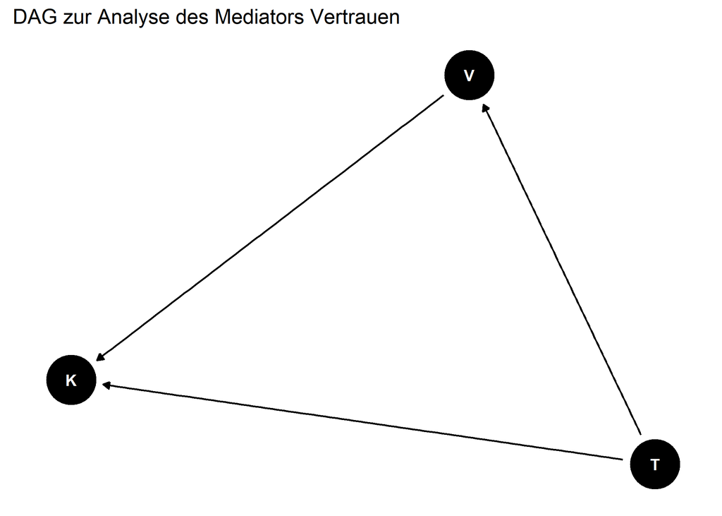

**Beschreibung des DAGs:**  
Das vorliegende Diagramm ist ein DAG, der die vermuteten kausalen Beziehungen zwischen drei zentralen Variablen darstellt: Treatment (T), Vertrauen (V) und Kaufbereitschaft (K). Die Variablen sind durch Pfeile miteinander verbunden, die die angenommene Richtung der kausalen Einflüsse anzeigen. Konkret sind Pfeile von T zu V, von V zu K und ein direkter Pfeil von T zu K vorhanden.

**Interpretation des DAGs**  
Dieses DAG visualisiert ein klassisches Mediationsmodell, das erklärt, wie das Treatment (Kostentransparenz) die Kaufbereitschaft beeinflusst. Der Pfeil von T zu V (T → V) drückt die Hypothese aus, dass die Kostentransparenz das Vertrauen in ein Unternehmen kausal beeinflusst. Der Pfeil von V zu K (V → K) postuliert, dass dieses gestärkte Vertrauen wiederum kausal die Kaufbereitschaft erhöht. Der direkte Pfeil von T zu K (T → K) berücksichtigt, dass die Kostentransparenz die Kaufbereitschaft auch direkt beeinflussen könnte, beispielsweise durch die einfache Verfügbarkeit von Informationen oder ein Signal von Fairness, das nicht vollständig durch die Variable Vertrauen erfasst wird. Das Modell geht davon aus, dass der Gesamteffekt der Kostentransparenz auf die Kaufbereitschaft sich aus einem indirekten Effekt über Vertrauen und einem direkten Effekt zusammensetzt.

**Begründen und erklären Sie die Struktur und den Aufbau ihres DAGs.**  
Die Struktur des DAGs ist darauf ausgelegt, den Mechanismus zu untersuchen, durch den Kostentransparenz (T) die Kaufbereitschaft (K) beeinflusst. Der Aufbau T → V basiert auf der Annahme, dass Transparenz ein Signal für Offenheit ist, welches das Vertrauen fördern kann. Der Pfad V → K ist begründet durch die bekannte psychologische Verbindung, dass Vertrauen Konsumenten dazu bringt, eher Produkte zu kaufen. Der zusätzliche direkte Pfad T → K wird einbezogen, da Transparenz auch auf anderen Wegen, jenseits des Vertrauens, eine direkte Wirkung auf die Kaufbereitschaft haben kann, zum Beispiel durch die Wahrnehmung von Fairness oder die Klarheit der Informationen.

**Welche Annahmen müssen getroffen werden, damit Vertrauen tatsächlich als Mediator interpretiert werden kann?**  
Damit Vertrauen als Mediator des Effekts von Treatment auf Kaufbereitschaft interpretiert werden kann, müssen bestimmte Annahmen erfüllt sein. Erstens muss das Treatment kausal das Vertrauen beeinflussen, und zweitens muss das Vertrauen kausal die Kaufbereitschaft beeinflussen. Entscheidend ist auch, dass keine ungemessenen Störfaktoren existieren, die sowohl den Mediator als auch das Outcome beeinflussen und somit den Mediationseffekt verzerren würden. Des Weiteren darf keine umgekehrte Kausalität vorliegen, also dass die Kaufbereitschaft das Vertrauen beeinflusst oder das Vertrauen das Treatment.

**Welche Verzerrungen oder Störfaktoren könnten den Mediator-Effekt von Vertrauen beeinflussen? Wie könnte dies die Ergebnisse verzerren?**  
Der Mediator-Effekt von Vertrauen könnte durch ungemessene Störfaktoren zwischen Vertrauen und Kaufbereitschaft beeinflusst werden. Zum Beispiel könnten eine allgemeine positive Einstellung zur Marke oder die persönliche Präferenz für nachhaltige Produkte sowohl das Vertrauen als auch die Kaufbereitschaft steigern, ohne dass dies durch das Treatment verursacht wird oder gemessen wurde. Solche ungemessenen Störfaktoren könnten dazu führen, dass der geschätzte Mediationseffekt von Vertrauen überschätzt wird. Auch Messfehler bei der Erfassung von Vertrauen oder Kaufbereitschaft können die geschätzten Effekte verzerren, typischerweise indem sie die Stärke des indirekten Effekts unterschätzen.

15. Führen Sie nun eine Regression durch, bei der Ihnen `trust` (Vertrauen) als abhängige Variable dient. Weiterhin soll ihnen `treatment` als erklärende Variable dienen. Erstellen sie eine weitere Regression, die zusätzlich noch für die folgenden Variablen kontrolliert: Alter, Einkommensniveau, Bildungsstufe und ob die Personen weiblich sind.

Stellen Sie die Regressionsergebnisse in einer Tabelle mit stargazer oder modelsummary dar!

Beschreiben und interpretieren Sie ihre Ergebnisse. Gehen Sie bei der Interpretation der Ergebnisse insbesondere auf folgende Fragen ein:

- Macht es ihrer Ansicht nach Sinn auf die zusätzlichen Variablen in Regression 2 zu kontrollieren? Worauf müssen Sie besonders achten?
- Was bedeutet ein signifikanter positiver Koeffizient für treatment in Bezug auf Vertrauen?
- Warum ist dieser Pfad (Treatment ➝ Trust) notwendig, damit eine Mediation überhaupt möglich ist?
- Überlegen Sie, ob andere Faktoren, die Sie möglicherweise nicht berücksichtigt haben, diesen Zusammenhang ebenfalls erklären könnten.

|  | Regressionsmodell Vertrauen (trust) Ohne Kontrollvariablen | Regressionsmodell Vertrauen (trust) Mit Kontrollvariablen |
| --- | --- | --- |
| (Intercept) | 4.821 | 4.716 |
|  | (0.079) | (0.320) |
| treatment | 0.473 | 0.454 |
|  | (0.112) | (0.113) |
| age |  | -0.001 |
|  |  | (0.005) |
| income |  | -0.021 |
|  |  | (0.024) |
| educ |  | 0.058 |
|  |  | (0.067) |
| female |  | 0.179 |
|  |  | (0.114) |
| Num.Obs. | 601 | 601 |
| R2 | 0.029 | 0.035 |
| R2 Adj. | 0.027 | 0.027 |
| AIC | 2091.3 | 2095.6 |
| BIC | 2104.5 | 2126.4 |
| Log.Lik. | -1042.644 | -1040.795 |
| F | 17.791 | 4.291 |
| RMSE | 1.37 | 1.37 |

Die Tabelle zeigt die Ergebnisse eines “Regressionsmodell Vertrauen (trust)”. Das bedeutet, sie analysiert, welche Faktoren die abhängige Variable “Vertrauen” beeinflussen. Es werden zwei Modelle verglichen:

Ohne Kontrollvariablen: Ein einfaches Modell, das nur den Einfluss der “treatment”-Variable auf das Vertrauen misst.

Mit Kontrollvariablen: Ein erweitertes Modell, das zusätzlich den Einfluss von Alter (age), Einkommen (income), Bildung (educ) und Geschlecht (female) berücksichtigt.

**Macht es Sinn, auf die zusätzlichen Variablen in Regression 2 zu kontrollieren?** Auch wenn das Treatment zufällig zugewiesen wurde (Randomisierung), kann es sein, dass einzelne Variablen wie Alter, Einkommen, Bildung oder Geschlecht leicht ungleich verteilt sind oder mit der Zielvariable (Vertrauen) korrelieren. Diese Kontrollvariablen helfen dabei: -Störfaktoren auszuschließen, die das Ergebnis verzerren könnten. -Die Präzision der Schätzung zu erhöhen (kleinere Standardfehler). -Robustheit der Ergebnisse zu prüfen.

In diesem Fall ändert sich der Treatment-Koeffizient nur leicht von 0.473 auf 0.454 – das deutet darauf hin, dass die zusätzlichen Variablen den Effekt kaum beeinflussen, die Kontrolle aber dennoch zur Absicherung sinnvoll ist.

**Was bedeutet ein signifikanter positiver Koeffizient für treatment in Bezug auf Vertrauen?** Ein signifikanter positiver Koeffizient (hier ca. 0.47) bedeutet: Teilnehmer im Treatment zeigen im Schnitt ein höheres Vertrauen in Everlane als Teilnehmer in der Kontrollgruppe. Dieser Effekt ist statistisch signifikant, da der Standardfehler relativ klein ist (ca. 0.11) → Der Zusammenhang ist nicht zufällig. Der Effekt ist auch inhaltlich bedeutsam, weil Vertrauen ein wichtiger Prädiktor für spätere Kaufabsichten sein kann.

**Warum ist dieser Pfad (Treatment ➝ Trust) notwendig, damit eine Mediation überhaupt möglich ist?** In einer Mediationsanalyse wird geprüft, ob die Wirkung einer unabhängigen Variable (Treatment) auf die abhängige Variable (Kaufbereitschaft) über eine dritte Variable (Mediator: Vertrauen) verläuft. Dazu muss zunächst überhaupt ein signifikanter Zusammenhang zwischen Treatment und Mediator bestehen (also: Treatment ➝ Trust). Ohne diesen Effekt ist eine Mediation nicht möglich, da kein indirekter Pfad besteht.

**Können andere unbeobachtete Faktoren diesen Zusammenhang erklären?** Mögliche unbeachtete Störfaktoren könnten sein: -Persönlichkeitsmerkmale wie Misstrauen oder Neigung zu Transparenzorientierung -Politische Einstellung oder Werte, z.B. Konsumethik -Erfahrungen mit ähnlichen Marken oder vorherige Markenbekanntheit -Soziale Einflüsse durch Peers oder Mediennutzung

Solche Variablen könnten mit sowohl dem Treatment (z.B. wie aufmerksam jemand auf Preisdetails achtet) als auch dem Vertrauen zusammenhängen – und so eine Scheinbeziehung erzeugen.

16. Nachdem Sie nun den Effekt des Treatments auf das Vertrauen geschätzt und ausgewertet haben, sollen Sie nun testen, ob das Vertrauen als Mediator zwischen Treatment und Kaufabsicht wirkt.

Führen Sie eine Regression durch, bei der Ihnen die Kaufbereitschaft als abhängige Variable dient. Weiterhin sollen die erklärende Variablen nun `treatment`, sowie das Vertrauen (`trust`) umfassen. Erstellen sie eine weitere Regression, die zusätzlich noch auf Alter, Einkommensniveau, Bildungsstufe und ob die Personen weiblich sind, kontrolliert.

Stellen Sie die Regressionsergebnisse passend in einer Tabelle dar!

Beschreiben und interpretieren Sie ihre Ergebnisse. Gehen Sie bei der Interpretation der Ergebnisse insbesondere auf folgende Fragen ein:

- Was könnten Ihrer Ansicht nach Gründe sein, dass `treatment` jetzt nicht mehr signifkant ist? Woran könnt das im Detail liegen?
- Warum ist es wichtig, `trust` und `treatment` gemeinsam in einem Modell zu betrachten?
- Warum könnte `trust` eine “notwendige Bedingung” sein, damit Transparenz der Kostenstruktur zu höherer Kaufbereitschaft führt?

|  | Regressionsmodell Kaufbereitschaft (wtb) Ohne Kontrollvariablen | Regressionsmodell Kaufbereitschaft (wtb) Mit Kontrollvariablen |
| --- | --- | --- |
| (Intercept) | -0.178 | -0.155 |
|  | (0.260) | (0.457) |
| treatment | 0.148 | 0.129 |
|  | (0.140) | (0.140) |
| trust | 0.813 | 0.818 |
|  | (0.050) | (0.050) |
| age |  | -0.013 |
|  |  | (0.006) |
| income |  | 0.041 |
|  |  | (0.030) |
| educ |  | 0.055 |
|  |  | (0.082) |
| female |  | -0.148 |
|  |  | (0.140) |
| Num.Obs. | 601 | 601 |
| R2 | 0.317 | 0.327 |
| R2 Adj. | 0.315 | 0.320 |
| AIC | 2337.9 | 2337.7 |
| BIC | 2355.5 | 2372.9 |
| Log.Lik. | -1164.952 | -1160.835 |
| F | 139.008 | 48.027 |
| RMSE | 1.68 | 1.67 |

Diese Tabelle zeigt ein “Regressionsmodell Kaufbereitschaft (wtb)”, wobei “wtb” wahrscheinlich für “Willingness to Buy” (Kaufbereitschaft) steht. Das Modell analysiert, welche Faktoren die Kaufbereitschaft der Teilnehmer beeinflussen. In diesem Modell ist “trust” (Vertrauen) nicht mehr die Ergebnisvariable, sondern eine der unabhängigen Variablen, die die Kaufbereitschaft erklären sollen.

**Warum ist treatment jetzt nicht mehr signifikant?** In beiden Modellen (mit und ohne Kontrolle) ist der Koeffizient für treatment (0.148 bzw. 0.129) nicht signifikant (Standardfehler: 0.140). Mögliche Gründe:

-Mediation durch Vertrauen (trust) Der Effekt von treatment auf Kaufbereitschaft scheint über Vertrauen zu laufen. In der vorherigen Regression war treatment signifikant für trust, und nun ist trust stark signifikant für Kaufbereitschaft. Sobald trust im Modell ist, nimmt treatment keine eigenständige Rolle mehr ein – das spricht für eine Mediationsbeziehung.

-Multikollinearität trust und treatment sind korreliert (da treatment Vertrauen beeinflusst). Das kann die Schätzung von treatment instabil machen, wenn beide gleichzeitig im Modell stehen. Der Effekt von treatment wird vom trust-Koeffizienten „aufgefangen“.

-Indirekter Effekt Der Effekt des treatment ist indirekt und wirkt fast ausschließlich über trust. Ohne trust im Modell hätte treatment vielleicht wieder einen signifikanten Effekt.

**Warum ist es wichtig, trust und treatment gemeinsam in einem Modell zu betrachten?**

Nur so kann getestet werden, ob: trust als Mediator wirkt – also ob es den Effekt von treatment erklärt. Es einen indirekten Pfad gibt: treatment ➝ trust ➝ wtb. Der direkte Effekt von treatment (nach Einfügen von trust) noch relevant ist → dies bestimmt, ob es sich um komplette oder partielle Mediation handelt. In Ihrem Fall scheint der direkte Effekt zu verschwinden, was auf eine vollständige Mediation hindeutet.

**Warum könnte trust eine notwendige Bedingung sein, damit Transparenz zu höherer Kaufbereitschaft führt?** Vertrauen fungiert hier als psychologischer Mechanismus, der die Wirkung erklärt:

-Transparenz (über treatment) erzeugt Glaubwürdigkeit. -Diese Glaubwürdigkeit führt zu mehr Vertrauen in die Marke. -Nur wenn dieses Vertrauen aufgebaut wird, steigt auch die Kaufbereitschaft.

Ohne Vertrauen wäre Transparenz neutral oder sogar irritierend, da Konsument:innen Preisstrukturen ohne Kontext oder Beziehung nicht automatisch positiv bewerten.

In den vorangegangenen Modellen wurde untersucht, ob das Treatment (Kostentransparenz) das Vertrauen in das Unternehmen beeinflusst und ob Vertrauen wiederum mit der Kaufabsicht zusammenhängt.

17. Bewerten Sie das experimentelle Design der Studie 2. Gehen Sie dabei auch darauf ein, inwiefern Ihre Ergebnisse aus Aufgabe 13 bis 16 das theoretische Verständnis von Vertrauensbildung in der Konsumentenpsychologie bestätigt oder infrage stellt. Welche Stärken und Schwächen sehen Sie bezüglich der internen Validität und der Kausalitätsaussagen? Diskutieren Sie zudem kurz, inwiefern die Ergebnisse auf andere Bevölkerungsgruppen oder kulturelle Kontexte übertragbar sind.

*Hinweis:* Informationen zum Verständnis der Vertrauensbildung in der Konsumentenpsychologie können Sie [in dem folgenden Artikel](https://www.shs-conferences.org/articles/shsconf/pdf/2021/26/shsconf_appsconf2021_03019.pdf) auf Seite 2 bis 5 nachlesen.

**Experimentelles Design** Das Design von Studie 2 basiert auf einem zwischen-subjektiven Ansatz mit zwei Gruppen: einer Kontrollgruppe, die nur Standard-Produktinformationen erhielt, und einer Treatmentgruppe, die zusätzlich eine detaillierte Kostenaufstellung präsentierte. Die abhängigen Variablen – Vertrauen in die Marke und Kaufbereitschaft – wurden über Fragebögen erfasst. Dieses einfache, aber zielgerichtete Design erlaubt eine klare Untersuchung des Einflusses von Kostentransparenz auf Vertrauen und Kaufverhalten.

**Stärken und Schwächen bezüglich interner Validität und Kausalität** Eine Stärke des Designs liegt in der randomisierten Zuweisung der Probanden zu den Gruppen, wodurch viele potenzielle Störfaktoren kontrolliert werden konnten. Zudem ist die experimentelle Manipulation der Kostentransparenz klar und nachvollziehbar, was eine gute Grundlage für kausale Schlussfolgerungen bietet. Die Erfassung von Vertrauen als potenziellen Mediator zwischen Treatment und Kaufbereitschaft unterstützt die Prüfung eines theoretisch fundierten Wirkmechanismus.

Auf der anderen Seite könnte die interne Validität durch mögliche Verzerrungen eingeschränkt sein. So ist nicht ausgeschlossen, dass weitere nicht erfasste Faktoren wie Vorerfahrungen mit der Marke oder individuelle Präferenzen die Ergebnisse beeinflussen. Auch das Fehlen einer Manipulationskontrolle (ob Teilnehmer die Kostentransparenz tatsächlich wahrnahmen und verstanden) schränkt die Aussagekraft etwas ein.

**Bestätigung oder Infragestellung des theoretischen Verständnisses von Vertrauen** Die Ergebnisse aus Aufgabe 13 bis 16 bestätigen das theoretische Modell, das Vertrauen als zentralen Mechanismus in der Konsumentenpsychologie beschreibt. Die signifikant höheren Vertrauenswerte in der Treatmentgruppe sowie die deutliche Korrelation zwischen Vertrauen und Kaufbereitschaft stützen die Annahme, dass Vertrauen das Bindeglied zwischen Kostentransparenz und Kaufentscheidung darstellt. Dies entspricht den theoretischen Annahmen, dass Vertrauen Risikoaversion reduziert und die Kaufbereitschaft fördert.

**Übertragbarkeit auf andere Bevölkerungsgruppen und kulturelle Kontexte** Die Generalisierbarkeit der Ergebnisse ist eingeschränkt, da die Stichprobe vermutlich homogen und kulturell begrenzt ist. Kulturelle Unterschiede in der Wahrnehmung von Transparenz, Vertrauen und Konsumverhalten könnten die Effekte moderieren. Insbesondere in Kulturen mit niedrigem Vertrauen in Unternehmen oder anderen sozialen Normen könnte der Einfluss der Kostentransparenz variieren. Zukünftige Studien sollten daher verschiedene Bevölkerungsgruppen und kulturelle Kontexte einbeziehen, um die Robustheit der Befunde zu prüfen.

**Zusammenfassung** Das experimentelle Design von Studie 2 ist geeignet, um den Einfluss von Kostentransparenz auf Vertrauen und Kaufbereitschaft kausal zu untersuchen. Die Ergebnisse bestätigen das theoretische Verständnis von Vertrauen als zentralem psychologischen Mechanismus. Einschränkungen hinsichtlich interner Validität und Generalisierbarkeit sind zu beachten, jedoch bieten die Befunde wichtige Hinweise für Marketingstrategien, die Vertrauen gezielt stärken wollen.

# Zusatzaufgabe

Zu Beginn des Projektes hatten wir erwähnt, dass die Experimente, welche im Projekt durchgeführt wurden, auf Grund eines Missgeschicks in der Online-Darstellung von unterschiedlichen Produkten zustande kam. Hier wurden von einem privat geführten Online-Händler Geldbörsen in fünf Farbvarianten angeboten, wobei beabsichtigt war, allen Farben eine einheitliche Kostentransparenz-Infografik zuzuordnen. Aufgrund eines Versehens wurde die Infografik jedoch nur bei drei Farben implementiert. Dieses zufällige Ereignis führte zu einer klaren Trennung zwischen den Produkten mit dieser und ohne diese Infografik. Das dadurch entstandene natürliche Experiment sollen Sie sich in der Zusatzaufgabe näher anschauen.

18. Lesen Sie sich den nachfolgenden Text zum Aufbau des natürlichen Experiments innerhalb dieses Papers durch und beantworten anschließend nachfolgende Fragen:

On December 2, 2013, a privately held online retailer launched a holiday gift shop with a single email to its mailing list, promoting a leather wallet offered in five colors (burgundy, black, grey, bone, and tan) and priced at $115.00. Later, at the end of January, to boost post-holiday sales, the retailer decided to add a cost transparency infographic to the online product detail pages for each of the wallet’s five color combinations. The retailer’s intention was to use the same infographic for all wallets since they differed only in color.

However, due to an inadvertent mistake, the infographic was not introduced for two of the wallet colors (bone and tan). Consequently, the cost transparency information was implemented for only three of the five wallet colors (burgundy, black, and grey) over a period of five weeks. This error created a natural experiment, enabling us to test the impact of cost transparency on wallet sales.

Therefore we have the following procedure:

- Operationalization of Cost Transparency: The infographic presented the total cost to produce the wallet, breaking it down into its specific components, namely: leather (14.68 US-Dollar), construction (38.56 US-Dollar), duties (4.26 US-Dollar), and transportation (1.00 US-Dollar). In addition, it included benchmark information indicating that the wallet had a 1.9x markup, in contrast to a 6x markup charged by a competitor. Because wallet colors serve as the basis for treatment assignment, the natural experiment compares “cost transparent” wallets (burgundy, black, and grey) to “non-transparent” wallets (bone and tan).
- Identification Strategy: We use a difference-in-differences approach to compare the daily sales between the treatment (cost transparency) and control (no cost transparency) groups before versus after the introduction of the infographic. By doing so, the design isolates the causal effect of cost transparency on the daily count of wallets sold for each color.
- Control Variables: Given that the cost transparency treatment was implemented by wallet color, and with only five available colors, it was necessary to control for potential confounders. For instance, we include a proxy for time-varying color popularity - the number of page views each wallet color received - and a proxy for time-varying inventory levels.

Beantworten Sie nun die folgenden Fragen in Bezug auf den vorherigen Text:

- Wie ist das natürliche Experiment aufgebaut, und warum wird es als solches klassifiziert?
- Welche Rolle spielt das zufällige Versäumnis, die Infografik bei zwei der fünf Farbvarianten einzuführen, in der Experimentstruktur?
- Warum ist es notwendig, Variablen wie Seitenaufrufe und Lagerbestandsproxies in die Analyse einzubeziehen?
  - Welche potenziellen Verzerrungen könnten auftreten, wenn diese Kontrollvariablen nicht berücksichtigt werden?

**Wie ist das natürliche Experiment aufgebaut, und warum wird es als solches klassifiziert?** Das natürliche Experiment basiert auf einem unbeabsichtigten Fehler in der Online-Darstellung eines Produkts: Ein Online-Händler wollte ursprünglich bei allen fünf Farbvarianten einer Geldbörse eine einheitliche Infografik zur Kostentransparenz hinzufügen. Durch ein Versehen wurde diese jedoch nur bei drei Farben (burgundy, black, grey) implementiert, während zwei Farben (bone, tan) keine solche Darstellung erhielten. Da die Zuordnung zur Treatment- oder Kontrollgruppe (mit vs. ohne Infografik) nicht durch aktives Eingreifen der Forschenden, sondern zufällig durch ein technisches Versehen entstand, spricht man von einem natürlichen Experiment. Diese zufällige Variation erfüllt zentrale Bedingungen eines experimentellen Designs, insbesondere hinsichtlich der quasi-randomisierten Zuweisung, was Kausalitätsaussagen ermöglicht.

**Welche Rolle spielt das zufällige Versäumnis, die Infografik bei zwei der fünf Farbvarianten einzuführen, in der Experimentstruktur?** Das Versäumnis stellt das zentrale Element dar, das die Trennung zwischen Behandlungs- und Kontrollgruppe überhaupt ermöglicht. Es sorgt dafür, dass drei Farben unbeabsichtigt dem Treatment (mit Infografik) und zwei Farben der Kontrollgruppe (ohne Infografik) zugeordnet wurden. Da diese Zuweisung nicht strategisch oder auf Grundlage anderer Variablen erfolgte, sondern durch Zufall, entsteht ein natürlicher Vergleich zwischen Gruppen mit und ohne Kostentransparenz, unter weitgehend gleichen Rahmenbedingungen. Dieses zufällige Ereignis schafft also die methodische Grundlage zur Analyse eines kausalen Zusammenhangs zwischen Kostentransparenz und Verkaufszahlen.

**Warum ist es notwendig, Variablen wie Seitenaufrufe und Lagerbestandsproxies in die Analyse einzubeziehen?** Da das Treatment nicht individuell, sondern nach Farbe erfolgt, könnten andere farbspezifische Effekte das Ergebnis verzerren. Wenn beispielsweise eine bestimmte Farbe beliebter ist oder häufiger beworben wurde, könnten sich Unterschiede in den Verkaufszahlen nicht nur auf die Infografik, sondern auch auf unterschiedliche Sichtbarkeit bzw. Seitenaufrufe oder Verfügbarkeit/Lagerbestand zurückführen lassen.

Seitenaufrufe dienen als Proxy für Nachfrage oder Sichtbarkeit im Zeitverlauf. Wird eine Farbe z.B. häufiger aufgerufen, steigen unabhängig von der Infografik die Verkaufschancen. Lagerbestände beeinflussen die tatsächliche Möglichkeit zum Kauf. Ist eine Farbe häufiger ausverkauft oder nur in geringer Stückzahl verfügbar, könnten Verkaufszahlen fälschlich als Effekt der Kostentransparenz interpretiert werden.

**Welche potenziellen Verzerrungen könnten auftreten, wenn diese Kontrollvariablen nicht berücksichtigt werden?** Ohne die Kontrolle dieser Variablen könnten sogenannte Scheineffekte auftreten, ein Beispiel wäre: Eine Farbe ohne Infografik verkauft sich schlechter, nicht wegen der fehlenden Transparenz, sondern weil sie seltener aufgerufen wurde oder nur noch wenige Exemplare verfügbar waren.

Solche Verzerrungen würden die Validität der Ergebnisse gefährden, insbesondere die interne Validität und die kausale Interpretierbarkeit der Differenz-in-Differenzen-Schätzung. Die Einbeziehung von Seitenaufrufen und Lagerdaten hilft also, alternative Erklärungen zu kontrollieren und die Isolierung des echten Effekts der Infografik auf den Verkaufserfolg zu ermöglichen.

19. Lesen Sie weiterhin das Kapitel [“Difference-in-Differences” in Huntington-Klein (2021)](https://theeffectbook.net/ch-DifferenceinDifference.html), speziell Kapitel 18.1 und 18.2 und beantworten Sie die folgenden Fragen dazu:

Kann eine Difference-in-Differences-Regression helfen, den kausalen Effekt der Kostentransparenz auf die Verkaufszahlen zu identifizieren?

Gehen Sie bei der Beantwortung dieser Frage insbesondere auf die nachfolgenden Punkte ein:

- Welche Art von Variation nutzt eine DiD-Regression in diesem Fall zur Identifikation des Effekts?
- Welche Voraussetzung(en) müssen erfüllt sein, damit DiD eine gültige Kausalschätzung liefert?
  - Was bedeutet die „Parallel Trends“-Annahme in diesem Kontext?
  - Warum reicht es nicht aus, nur zu vergleichen, wie sich die Verkaufszahlen nach der Einführung verändert haben?
- Basierend auf dem Kontext des Buchkapitels zu Difference-in-Differences (DiD) und den Informationen aus `Aufgabe 18`, formulieren Sie bitte die **Regressionsgleichung**, mit der der Effekt der Kostentransparenzmaßnahme mithilfe eines DiD-Ansatzes untersucht werden kann.
  - Definieren Sie dabei klar alle verwendeten Variablen.
  - Stellen Sie die Regressionsgleichung in mathematischer Form dar.
  - Beschreiben und erklären Sie das von Ihnen aufgestellte Modell.

**Kann eine Difference-in-Differences-Regression helfen, den kausalen Effekt der Kostentransparenz auf die Verkaufszahlen zu identifizieren?** Ja, eine Difference-in-Differences (DiD)-Regression ist in diesem Fall ein geeignetes Werkzeug zur Identifikation des kausalen Effekts der Kostentransparenz auf die Verkaufszahlen. Das zugrunde liegende natürliche Experiment – ein unbeabsichtigtes Versäumnis bei der Einführung der Infografik – schafft dafür die methodische Grundlage.

**Welche Art von Variation nutzt eine DiD-Regression in diesem Fall zur Identifikation des Effekts?** Die DiD-Strategie nutzt zwei Dimensionen der Variation: **Zeitliche Variation:** Vorher–Nachher-Vergleich der Verkaufszahlen vor und nach der Einführung der Infografik (Post-Treatment-Zeitpunkt). **Gruppenvariation:** Vergleich zwischen Wallet-Farben, die mit Infografik (Treatment: burgundy, black, grey) und solchen, die ohne Infografik (Kontrolle: bone, tan) dargestellt wurden. Der entscheidende Identifikationshebel ist die Interaktion dieser beiden Dimensionen. Nur wenn eine Farbe behandelt wurde und in der Nachher-Periode liegt, wird ein Effekt erwartet. Diese doppelte Differenz eliminiert konstante Gruppenunterschiede sowie zeitgleiche externe Einflüsse und isoliert somit den kausalen Effekt der Kostentransparenz (siehe Kap. 18.2.1).

**Welche Voraussetzung(en) müssen erfüllt sein, damit DiD eine gültige Kausalschätzung liefert?** Die zentrale Voraussetzung für eine valide DiD-Schätzung ist die sogenannte Parallel-Trends-Annahme. Sie besagt, dass sich in Abwesenheit der Intervention (also ohne Infografik) die Verkaufszahlen beider Gruppen – Treatment und Kontrolle – parallel entwickelt hätten.

**Was bedeutet die „Parallel Trends“-Annahme in diesem Kontext?** Im konkreten Fall bedeutet die Annahme: Hätte es die Infografik nicht gegeben, wären die Verkaufszahlen der drei behandelten Wallet-Farben (burgundy, black, grey) in ähnlicher Weise verlaufen wie die der beiden Kontrollfarben (bone, tan). Das heißt, Unterschiede im Verkaufsverlauf nach Einführung der Infografik können dann mit hoher Wahrscheinlichkeit kausal auf die Kostentransparenzmaßnahme zurückgeführt werden – vorausgesetzt, diese Parallelität war vor der Intervention gegeben (vgl. Kap. 18.2.3).

**Warum reicht es nicht aus, nur zu vergleichen, wie sich die Verkaufszahlen nach der Einführung verändert haben?** Ein bloßer Vorher-Nachher-Vergleich innerhalb der Treatment-Gruppe würde alle anderen Einflüsse übersehen, die gleichzeitig mit der Einführung der Infografik wirken könnten – etwa saisonale Effekte, allgemeine Kaufzurückhaltung nach den Feiertagen oder externe Marketingmaßnahmen. Ohne Kontrollgruppe lässt sich nicht unterscheiden, ob Veränderungen wirklich auf die Infografik zurückzuführen sind oder auf externe Störfaktoren. Nur durch den Vergleich mit der Kontrollgruppe, die nicht behandelt wurde, kann geprüft werden, ob sich die Verkaufszahlen tatsächlich anders entwickelt haben als im kontrafaktischen Szenario. Genau diesen Mechanismus bildet DiD ab.

**Modell:**

Sales_it = a_i + b_t + ß1( Treatment_i * Post_t ) + ß2 * PageViews_it + ß3 * Inventory_it + u_it

**Erklärung der Bestandteile:** Sales_it: Anzahl der verkauften Wallets der Farbvariante i am Tag t.

Treatment_i: Indikatorvariable; 1, wenn Farbe i zur Behandlungsgruppe (mit Infografik) gehört, 0 sonst.

Post_t: Zeitindikator; 1 für Tage nach Einführung der Infografik, 0 sonst.

Treatment_i × Post_t: Interaktionsterm, der nur dann 1 ist, wenn eine behandelte Farbe in der Nachher-Periode beobachtet wird – der zentrale DiD-Indikator.

PageViews_it: Anzahl der Seitenaufrufe der Farbvariante i an Tag t - Proxy für Sichtbarkeit bzw. Nachfrage.

Inventory_it: Anzahl der verfügbaren Einheiten der Farbe i an Tag t - kontrolliert Angebotsrestriktionen.

a_i: Farb-spezifische Fixed Effects; kontrollieren für zeitlich konstante Unterschiede zwischen Wallet-Farben.

b_t: Tages-spezifische Fixed Effects; kontrollieren für externe Effekte, die alle Farben am gleichen Tag beeinflussen (z. B. Wochentage, Feiertage).

u_it: Fehlerterm; unbeobachtete Störfaktoren, die die Verkaufszahlen beeinflussen können.

**Beschreibung und Erklärung des Regressionsmodells:** Das Modell zielt darauf ab, den kausalen Effekt der Kostentransparenz-Infografik auf die Verkaufszahlen der verschiedenen Wallet-Farben zu schätzen. Es basiert auf einem Difference-in-Differences-Ansatz, der sowohl zeitliche als auch gruppenspezifische Variation berücksichtigt. Die abhängige Variable Sales_it misst die Verkaufszahlen der jeweiligen Wallet-Farbe i am Tag t. Die zentrale erklärende Variable ist der Interaktionsterm Treatment_i Post_t. Dieser Term ist genau dann eins, wenn eine behandelte Farbe in der Nachher-Periode beobachtet wird, und misst somit den spezifischen Effekt der Kostentransparenzmaßnahme.

Zusätzlich kontrolliert das Modell für zwei wichtige Einflussgrößen: PageViews_it als Proxy für Sichtbarkeit und potentielle Nachfrage sowie Inventory_it als Maß für die Verfügbarkeit der jeweiligen Farbe, was direkte Auswirkungen auf die Verkaufszahlen haben kann. Die Farb-spezifischen Fixed Effects a_i berücksichtigen zeitlich konstante Unterschiede zwischen den Farben, wie z. B. Grundbeliebtheit oder Preissegment, um Verzerrungen zu vermeiden. Die Tages-Fixed Effects b_t erfassen externe Einflüsse, die alle Farben an einem bestimmten Tag gleichermaßen beeinflussen, wie saisonale Effekte oder besondere Ereignisse. Der Fehlerterm u_it fasst alle übrigen unbeobachteten Faktoren zusammen, die Einfluss auf die Verkaufszahlen haben, aber nicht explizit modelliert werden. Unter der Annahme, dass ohne Einführung der Infografik die Verkaufszahlen von Behandlungs- und Kontrollgruppe parallel verlaufen wären („Parallel-Trends-Annahme“), lässt sich der Koeffizient ß1 kausal als durchschnittlicher Effekt der Kostentransparenz interpretieren. Die Einbeziehung von Kontrollvariablen und Fixed Effects minimiert Verzerrungen und stärkt die interne Validität der Schätzung.

**Fazit:** Die Difference-in-Differences-Regression stellt unter Berücksichtigung der Parallel-Trends-Annahme und relevanter Kontrollvariablen ein robustes methodisches Instrument dar, um den kausalen Einfluss der Kostentransparenz-Infografik auf die Verkaufszahlen zu identifizieren. Das natürliche Experiment, das durch einen zufälligen Fehler entstand, bietet hierfür eine geeignete quasi-experimentelle Grundlage.

20. Zum Abschluss des Projekts sollen Sie sich das oben beschriebene natürliche Experiment genauer anschauen. Lesen Sie hierzu die Daten (`Experiment3.csv`) in R ein. Nennen Sie den Datensatz `daten_exp3`. Erstellen Sie eine Variable `log_units`, die die logarithmierte Anzahl an verkauften Einheiten darstellt.

Erstellen Sie weiterhin eine passende Grafik, die die durchschnittliche Anzahl der verkauften Produkte je Treatment pro Woche abbildet. Fügen Sie weiterhin eine vertikale Linie für den 28. Januar 2014 in ihre Grafik ein, welche die Einführung der Kostentransparenz markiert.

Beschreiben und interpretieren Sie ihre Grafik. Gehen Sie insbesondere auf die Entwicklung der durchschnittlichen Verkaufszahlen in beiden Gruppen vor und nach dem 28. Januar ein. Gibt es visuelle Hinweise auf eine Wirkung der Kostentransparenz?

- Angenommen, beide Gruppen (Treatment und Kontrolle) zeigen vor der Einführung der Kostentransparenz einen gleich starken Anstieg der durchschnittlich verkauften Einheiten. Was würde das für die Interpretation der Maßnahme im Rahmen eines Difference-in-Differences-Ansatzes bedeuten?

*Hinweis:* Für die Ableitung der Wochen aus dem Datumsformat kann die Funktion `isoweek()` aus dem Paket `lubridate` verwendet werden.

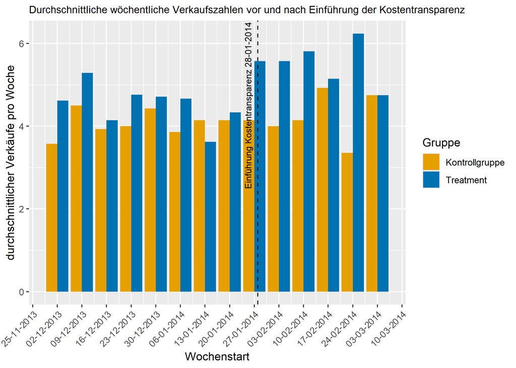

**Beschreibung und Interpretation der Grafik zur Wirkung der Kostentransparenz:** Die dargestellte Grafik visualisiert die durchschnittlich verkauften Einheiten pro Woche in einer Treatment- und einer Kontrollgruppe im Zeitraum vor und nach der Einführung der Kostentransparenz am 28. Januar 2014. Die vertikale gestrichelte Linie markiert diesen Zeitpunkt. Die Balken repräsentieren wöchentliche Mittelwerte der Verkaufszahlen und sind nach Gruppen farblich differenziert.

**Nach dem 28. Januar 2014** lässt sich visuell eine unterschiedliche Entwicklung beobachten: Während die Kontrollgruppe in ihrem Verkaufstrend relativ stabil bleibt, ist in der Treatment-Gruppe ein moderater Anstieg der durchschnittlichen Verkaufszahlen zu erkennen. Diese visuelle Divergenz zwischen den Gruppen nach der Intervention könnte als erster Hinweis auf einen kausalen Effekt der Kostentransparenz interpretiert werden.

**Einordnung im Rahmen des Difference-in-Differences-Ansatzes:** Im DiD-Ansatz ist es essenziell, dass sich beide Gruppen vor der Intervention ähnlich verhalten haben, also gleiche Trendverläufe aufweisen. Dies wird als Parallel-Trend-Annahme bezeichnet. Sollte, wie angenommen, in beiden Gruppen vor dem 28. Januar ein gleich starker Anstieg der Verkaufszahlen stattgefunden haben, würde dies die Gültigkeit der Parallelität untermauern. Unter dieser Voraussetzung kann ein beobachteter Unterschied nach der Maßnahme mit höherer Wahrscheinlichkeit auf die Intervention zurückgeführt werden, da alternative Erklärungsfaktoren, z.B. saisonale Effekte oder allgemeine Marktentwicklung, beide Gruppen gleichermaßen betreffen würden.

**Fazit:** Die beobachtete relative Zunahme der Verkaufszahlen in der Treatment-Gruppe im Vergleich zur Kontrollgruppe nach Einführung der Kostentransparenz deutet somit auf einen positiven kausalen Effekt der Maßnahme hin. Eine formale statistische Prüfung wäre jedoch erforderlich, um diese Hypothese empirisch zu stützen.

21. Erstellen Sie eine (mehrere) weitere passende Grafik(en), die die durchschnittlich verkauften Einheiten pro Tag in Treatment und Kontrolle vor und nach der Einführung der Kostentransparenz abbildet. Ergänzen Sie in ihrer Grafik die jeweiligen Standardfehler als Fehlerbalken. Beschreiben und interpretieren Sie ihre Grafik. Gehen Sie insbesondere auf die Unterschiede vor und nach der Einführung der Kostentransparenz ein.
- Inwiefern lassen sich daraus erste Hinweise auf einen möglichen Effekt des natürlichen Experiments erkennen?

*Hinweis:* Für die Erstellung der Grafik können Sie sich an Aufgabe 7 und 9 orientieren.

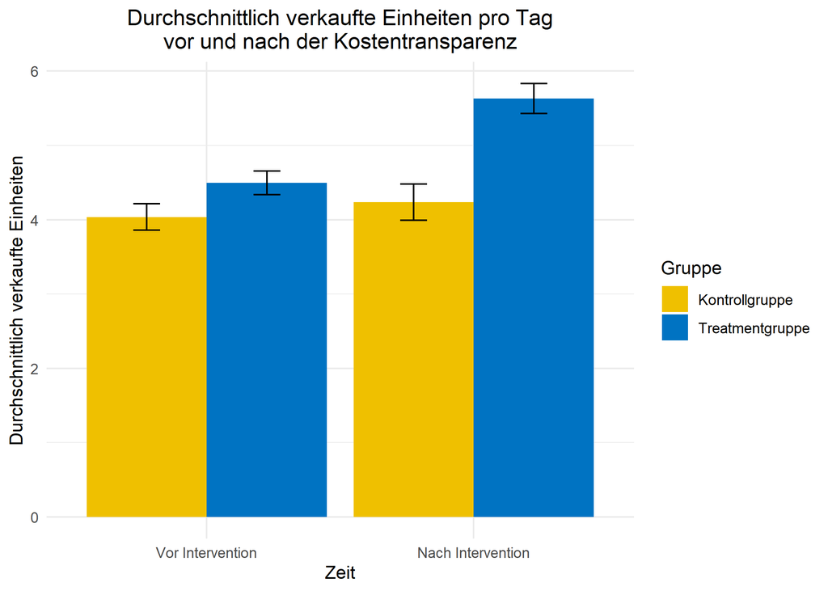

**Beschreibung und Inrerpretation:**

Vor der Einführung der Kostentransparenz bewegen sich die Verkaufszahlen für beide Gruppen relativ konstant. Nach der Einführung steigt die Verkaufszahl in der Treatment-Gruppe sichtbar schneller an als in der Kontrollgruppe. Die Kontrollgruppe zeigt eine weniger starke Veränderung, was darauf hindeutet, dass der beobachtete Effekt speziell durch die Kostentransparenz im Treatment beeinflusst wurde.

**Erste Hinweise auf einen möglichen Effekt des natürlichen Experiments**

- Trendänderung nach der Einführung: Die deutliche Veränderung in der Verkaufsdynamik der Treatment-Gruppe nach der Einführung deutet darauf hin, dass die Transparenzmaßnahme einen Einfluss auf das Kaufverhalten hatte.
- Unterschiede zwischen den Gruppen: Falls es vor der Einführung keine großen Unterschiede gab, aber nach der Einführung die Treatment-Gruppe einen stärkeren Anstieg zeigt, spricht dies für einen direkten Zusammenhang zwischen Kostentransparenz und höheren Verkaufszahlen.
- Zusätzliche Analysen nötig: Obwohl die Grafik visuell eine Wirkung nahelegt, ist eine statistische Überprüfung (wie Difference-in-Differences Regression) notwendig, um einen kausalen Effekt klar zu bestimmen.
22. In der vorherigen Aufgabe haben Sie den Effekt von Kostentransparenz auf die Verkaufszahlen anhand eines deskriptiven Vergleichs untersucht. Dabei haben Sie die durchschnittlich täglich verkauften Einheiten je Treatment vor und nach der Einführung der Transparenzmaßnahme grafisch gegenübergestellt. In dieser Aufgabe sollen Sie diesen Effekt nun ökonometrisch genauer untersuchen, indem Sie den Difference-in-Differences Ansatz in einem Regressionsrahmen anwenden.

Untersuchen Sie den Effekt der Einführung von Kostentransparenz auf die Verkaufszahlen mithilfe einer Difference-in-Differences Regression. Verwenden Sie hierfür Beobachtungen an Werktagen, sowie am Wochenende (Montag bis Sonntag), mit positiven Verkaufszahlen.

Erstellen Sie insgesamt zwei Regressionsmodelle:

- Basismodell ohne Kontrollvariablen
- Modell mit Kontrolle für Wochentagseffekte

Stellen Sie die Ergebnisse anschaulich dar. Beschreiben und interpretieren Sie Ihre Ergebnisse. Gehen Sie insbesondere auf folgende Aspekte ein.

- Wie würden Sie die Größe des Effekts interpretieren, den Sie für `treated:post` erhalten haben?
- Welche Vorteile bringt es, log_units (logarithmierte Verkäufe) als abhängige Variable zu verwenden?
- Können Sie aus Ihrer Schätzung auf einen kausalen Effekt der Kostentransparenz schließen?
- Inwiefern hilft die Kontrolle für Wochentage dabei, Verzerrungen in der Schätzung zu vermeiden?
- Würden Sie auf Basis Ihrer Analyse eine Empfehlung zur Beibehaltung oder Ausweitung der Kostentransparenz geben?
- Worin könnten ihrer Ansicht nach Probleme liegen bei der Betrachtung eines natürlichen Experiments, die die Ergebnisse verzerren könnten?

*Hinweis 1:* Nutzen Sie für die Schätzung die `feols()`-Funktion aus dem fixest-Paket.

*Hinweis 2:* Nutzen Sie die logarithmierten täglichen Verkaufszahlen als abhängige Variable.

|  | Effekt der Kostentransparenz auf log(units_sold) Ohne Wochentagskontrolle | Effekt der Kostentransparenz auf log(units_sold) Mit Wochentagskontrolle |
| --- | --- | --- |
| (Intercept) | 1.285*** | 1.169*** |
|  | (0.049) | (0.077) |
| treated | 0.105+ | 0.106+ |
|  | (0.063) | (0.063) |
| post | 0.066 | 0.064 |
|  | (0.077) | (0.077) |
| did | 0.182+ | 0.182+ |
|  | (0.099) | (0.099) |
| wday = Mo |  | 0.119 |
|  |  | (0.090) |
| wday = Di |  | 0.123 |
|  |  | (0.089) |
| wday = Mi |  | 0.243** |
|  |  | (0.089) |
| wday = Do |  | 0.026 |
|  |  | (0.089) |
| wday = Fr |  | 0.164+ |
|  |  | (0.091) |
| wday = Sa |  | 0.128 |
|  |  | (0.091) |
| Num.Obs. | 470 | 470 |
| R2 | 0.060 | 0.081 |
| R2 Adj. | 0.054 | 0.063 |
| AIC | 716.7 | 718.3 |
| BIC | 733.3 | 759.8 |
| RMSE | 0.51 | 0.51 |
| Std.Errors | IID | IID |

+ p < 0.1, * p < 0.05, ** p < 0.01, *** p < 0.001

Diese Tabelle zeigt die Ergebnisse einer Regressionsanalyse vom “Effekt der Kostentransparenz auf log(units_sold)”. Ziel der Analyse ist es, die Auswirkung einer Maßnahme zur Kostentransparenz auf die Verkaufszahlen (logarithmiert) zu messen. Die Methode ist ein Difference-in-Differences (DiD)-Ansatz.

Die Tabelle vergleicht zwei Modelle:

*Ohne Wochentagskontrolle*: Ein grundlegendes DiD-Modell.

*Mit Wochentagskontrolle*: Ein erweitertes Modell, das zusätzlich für die einzelnen Wochentage kontrolliert

**Interpretation des treated:post-Effekts**

Der geschätzte Koeffizient für DiD (treated:post) beträgt 0.182 mit einer Signifikanz von p < 0.1. Dies deutet darauf hin, dass die Einführung der Kostentransparenz einen positiven Einfluss auf die Verkaufszahlen im Treatment hatte. - Ein Wert von 0.182 bedeutet, dass die Verkaufszahlen im Treatment nach der Einführung der Kostentransparenz um etwa 18,2 % gestiegen sind (da log-Transformation genutzt wurde, kann die Interpretation als %-Änderung erfolgen). - Die statistische Signifikanz liegt bei p < 0.1, was eine gewisse Unsicherheit in der Schätzung zeigt, aber dennoch einen potenziellen Effekt nahelegt.

**Vorteile der logarithmierten Verkaufszahlen als abhängige Variable (log_units_sold)**

Die Verwendung von logarithmierten Verkaufszahlen hat mehrere Vorteile: - Interpretierbarkeit: Koeffizienten können als prozentuale Änderungen interpretiert werden. - Reduktion von Verzerrungen: Logarithmierung hilft, große Schwankungen in den Daten auszugleichen und extrem hohe Verkaufszahlen weniger dominant zu machen. - Normalisierung der Daten: Verkaufszahlen sind oft recht schief verteilt, und die Log-Transformation macht sie näher an einer Normalverteilung. Dies verbessert die Modellschätzungen und verringert heteroskedastische Probleme.

**Kausalität der Kostentransparenz**

Die Difference-in-Differences (DiD)-Methode ist eine gängige Technik zur Abschätzung kausaler Effekte, doch einige Einschränkungen müssen berücksichtigt werden: - Falls sich externe Faktoren geändert haben (z. B. saisonale Effekte oder makroökonomische Schocks), könnten diese den Effekt überlagern. - Falls die Treatment- und Kontrollgruppen nicht perfekt vergleichbar sind (unterschiedliche Ausgangsbedingungen), könnte der geschätzte Effekt verzerrt sein. - Wenn andere Maßnahmen zeitgleich mit der Kostentransparenz eingeführt wurden, ist eine eindeutige Zuordnung schwierig. Trotz dieser Einschränkungen deutet das Ergebnis darauf hin, dass Kostentransparenz einen positiven Einfluss haben könnte.

**Kontrolle für Wochentagseffekte zur Vermeidung von Verzerrungen**

Die Hinzunahme von Wochentagseffekten hilft, systematische Unterschiede zwischen einzelnen Tagen zu kontrollieren. - Der Mittwoch (wday = Mi) zeigt einen signifikanten positiven Effekt (0.243**), was darauf hindeutet, dass mittwochs allgemein mehr verkauft wird als an anderen Tagen. - Die Kontrolle der Wochentage verhindert, dass der DiD-Schätzer durch wiederkehrende wochentägliche Schwankungen beeinflusst wird. - Falls sich das Kaufverhalten z. B. zwischen Wochenenden und Werktagen stark unterscheidet, könnte ein Modell ohne diese Kontrolle eine falsche Schlussfolgerung ziehen.

**Empfehlung zur Beibehaltung oder Ausweitung der Kostentransparenz**

Die Kostentransparenz scheint einen positiven Effekt auf die Verkaufszahlen zu haben, wenn man die Schätzung des DiD-Effekts betrachtet. Basierend auf dieser Analyse könnte eine Beibehaltung oder sogar eine Ausweitung der Maßnahme sinnvoll sein. - Wenn weitere Daten zeigen, dass der Effekt auch längerfristig bestehen bleibt, könnte eine breitere Umsetzung in anderen Märkten oder Produktbereichen sinnvoll sein. - Falls sich jedoch der Effekt mit der Zeit abschwächt, wäre eine Kosten-Nutzen-Analyse wichtig, um abzuwägen, ob die Maßnahme weiterhin wirtschaftlich sinnvoll ist.

**Mögliche Verzerrungen in natürlichen Experimenten**

Obwohl natürliche Experimente nützlich sind, gibt es einige Herausforderungen: - Selbstselektion: Falls Kunden bewusst verschiedene Märkte aufsuchen, könnte eine systematische Verzerrung entstehen. - Externe Faktoren: Saisonale Effekte, Werbeaktionen oder wirtschaftliche Entwicklungen können den Verkauf beeinflussen. - Nicht-randomisierte Zuordnung: Falls die Treatment-Gruppe von Anfang an andere Kaufgewohnheiten hatte, ist es schwierig, den echten Effekt isoliert zu betrachten. - Zeiteffekte: Falls sich Kunden erst nach und nach an die Kostentransparenz gewöhnen, könnte der langfristige Effekt anders sein als der kurzfristige.

# Literatur

Mohan, B., Buell, R. W., & John, L. K. (2020). Lifting the veil: The benefits of cost transparency. Marketing Science, 39(6), 1105-1121. https://doi.org/10.1287/mksc.2019.1200

# Anhang

## Mediator

Im Rahmen von Mediationen ist der Mediator eine Variable, die den erklärenden Zusammenhang zwischen einer unabhängigen und einer abhängigen Variable vermittelt. Dabei wird untersucht, inwieweit der Einfluss der unabhängigen Variablen (z.B. Kostentransparenz) auf die abhängige Variable (z.B. Kaufabsicht) über einen vermittelnden Mechanismus - wie das Vertrauen der Kunden - erfolgt.

1. **Mediatoreffekt**: Der Mediatoren-Effekt, oft als ACME (Average Causal Mediation Effect) bezeichnet, beschreibt den indirekten Effekt, den die unabhängige Variable auf die abhängige Variable über den Mediator ausübt. Ist dieser Effekt signifikant, signalisiert dies, dass ein wesentlicher Teil des gesamten Einflusses über den vermittelnden Mechanismus läuft. Gleichzeitig kann ein nicht-signifikanter direkter Effekt (ADE - Average Direct Effect) darauf hindeuten, dass der Mediator den hauptsächlichen Erklärungsmechanismus darstellt.
2. **Funktion und Wirkung des Mediators**: Analog zum Konzept der signalgebenden Funktion bei Statussymbolen - deren Wert unter anderem von der Exklusivität und dem sozialen Kontext abhängt - fungiert der Mediator als vermittelnder Kanal, der erklärt, wie und warum der ursprüngliche Zusammenhang zwischen zwei Variablen zustande kommt. Der Mediator „überträgt“ quasi den Effekt der unabhängigen Variable auf die abhängige Variable. Dadurch kann in Modellen, in denen der direkte Zusammenhang zwischen der unabhängigen und der abhängigen Variable durch die Einbeziehung des Mediators verschwindet oder abgeschwächt wird, abgeleitet werden, dass der Mechanismus über den Mediator läuft. Dies ermöglicht ein tieferes Verständnis der zugrundeliegenden psychologischen Prozesse - etwa wie das Vertrauen der Kunden die Wirkung von Kostentransparenz auf deren Kaufabsicht vermittelt.

Zusammengefasst spielt der Mediator eine zentrale Rolle bei der Aufklärung der kausalen Mechanismen, indem er als vermittelnder Faktor zwischen Ursache und Wirkung identifiziert wird. Die signifikante Vermittlung über den Mediator zeigt, dass nicht allein das Vorhandensein von Kostentransparenz entscheidend ist, sondern auch, inwiefern diese Transparenz das Vertrauen stärkt - was wiederum maßgeblich die Kaufabsicht beeinflusst. So liefert die Mediationsanalyse wertvolle Einsichten, die über einfache bivariate Zusammenhänge hinausgehen und die Komplexität kausaler Mechanismen innerhalb von sozialen oder marktorientierten Prozessen sichtbar machen.